| [SOCR ≫](http://www.socr.umich.edu) | [DSPA ≫](http://Predictive.Space) | [Topics ≫](http://DSPA.predictive.space/) |
| --- | --- | --- |

# Data Science and Predictive Analytics (UMich HS650)

December 2018

The time-varying (longitudinal) characteristics of large information flows represent a special case of the complexity, dynamic and multi-scale nature of big biomedical data that we discussed in the [DSPA Motivation section](http://www.socr.umich.edu/people/dinov/2017/Spring/DSPA_HS650/notes/00_Motivation.html). Previously, in [Chapter 3](http://www.socr.umich.edu/people/dinov/courses/DSPA_notes/03_DataVisualization.html), we saw space-time (4D) functional magnetic resonance imaging (fMRI) data, and in [Chapter 15](http://www.socr.umich.edu/people/dinov/courses/DSPA_notes/15_SpecializedML_FormatsOptimization.html) we discussed streaming data, which also has a natural temporal dimension.

In this Chapter, we will expand our predictive data analytic strategies specifically for analyzing longitudinal data. We will interrogate datasets that track the same type of information, for same subjects, units or locations, over a period of time. Specifically, we will present time series analysis, forecasting using autoregressive integrated moving average (ARIMA) models, structural equation models (SEM), and longitudinal data analysis via linear mixed models.

*Note*: This Chapter is purposely divided in two separate sections to reduce the page loading time, stratify the extensive computational tasks, and improve the user experiences. The separate [RNN/LSTM section is available here](http://www.socr.umich.edu/people/dinov/courses/DSPA_notes/18_BigLongitudinalDataAnalysis_RNN.html), and it includes:

- Recurrent Neural Networks (RNN)
- Tensor Format Representation
- Simulated RNN case-study
- Climate Data Study
- Keras-based Multi-covariate LSTM Time-series Analysis and Forecasting.

# 1 Time series analysis

Time series analysis relies on models like [ARIMA (Autoregressive integrated moving average)](https://en.wikipedia.org/wiki/Autoregressive_integrated_moving_average) that utilize past longitudinal information to predict near future outcomes. Time series data tent to track univariate, sometimes multivariate, processes over a continuous time interval. The stock market, e.g., daily closing value of the [Dow Jones Industrial Average index](http://quotes.wsj.com/index/DJIA/historical-prices), or [electroencephalography (EEG) data](http://headit.org/) provide examples of such longitudinal datasets (time series).

The basic concepts in time series analysis include:

- The characteristics of *(second-order) stationary time series* (e.g., first two moments are stable over time) do not depend on the time at which the series process is observed.
- *Differencing* – a transformation applied to time-series data to make it stationary. Differences between consecutive time-observations may be computed by $\displaystyle y_{t}'=y_{t}-y_{t-1}$. Differencing removes the level changes in the time series, eliminates trend, reduces seasonality, and stabilizes the mean of the time series. Differencing the time series repeatedly may yield a stationary time series. For example, a second order differencing:
  $$\displaystyle {\begin{aligned}y_{t}^{''}&=y_{t}'-y_{t-1}'\\&=(y_{t}-y_{t-1})-(y_{t-1}-y_{t-2})\\&=y_{t}-2y_{t-1}+y_{t-2}\end{aligned}}.$$
- *Seasonal differencing* is computed as a difference between one observation and its corresponding observation in the previous epoch, or season (e.g., annually, there are $m=4$ seasons), like in this example:
  $$\displaystyle y_{t}'''=y_{t}-y_{t-m}\quad {\text{where }}m={\text{number of seasons}}.$$
  The differenced data may then be used to estimate an ARMA model.

We will use the [Beijing air quality PM2.5 dataset](https://umich.instructure.com/files/1823138/download?download_frd=1) as an example to demonstrate the analysis process. This dataset measures air pollutants - PM2.5 particles in micrograms per cubic meter during the past 9 years (2008-2016). It measures the *hourly average of the number of particles that are of size 2.5 microns (PM2.5)* once per hour in Beijing, China.

Let’s first import the dataset into `R`.

```r
beijing.pm25<-read.csv("https://umich.instructure.com/files/1823138/download?download_frd=1")
summary(beijing.pm25)
```

```
##      Index            Site       Parameter              Date..LST.
##  Min.   :    1   Beijing:69335   PM2.5:69335   3/13/2011 3:00:    2
##  1st Qu.:17335                                 3/13/2016 3:00:    2
##  Median :34668                                 3/14/2010 3:00:    2
##  Mean   :34668                                 3/8/2009 3:00 :    2
##  3rd Qu.:52002                                 3/8/2015 3:00 :    2
##  Max.   :69335                                 3/9/2014 3:00 :    2
##                                                (Other)       :69323
##       Year          Month             Day             Hour
##  Min.   :2008   Min.   : 1.000   Min.   : 1.00   Min.   : 0.0
##  1st Qu.:2010   1st Qu.: 4.000   1st Qu.: 8.00   1st Qu.: 5.5
##  Median :2012   Median : 6.000   Median :16.00   Median :11.0
##  Mean   :2012   Mean   : 6.407   Mean   :15.73   Mean   :11.5
##  3rd Qu.:2014   3rd Qu.: 9.000   3rd Qu.:23.00   3rd Qu.:17.5
##  Max.   :2016   Max.   :12.000   Max.   :31.00   Max.   :23.0
##
##      Value         Duration        QC.Name
##  Min.   :-999.00   1 Hr:69335   Missing: 4408
##  1st Qu.:  22.00                Valid  :64927
##  Median :  63.00
##  Mean   :  24.99
##  3rd Qu.: 125.00
##  Max.   : 994.00
##
```

```r
beijing.pm25[beijing.pm25$Value==-999, 9]<-NA
beijing.pm25[is.na(beijing.pm25$Value), 9]<-floor(mean(beijing.pm25$Value, na.rm = T))
```

Here we first reassign the missing values into `NA` labels. Then we replace all `NA` labels with the *mean* computed using all non-missing observations. Note that the `floor()` function casts the arithmetic averages as integer numbers, which is needed as AQI values are expected to be whole numbers.

Now, let’s observe the trend of hourly average PM2.5 across one day. You can see a significant pattern: The PM2.5 level peeks in the afternoons and is the lowest in the early mornings and exhibits approximate periodic boundary conditions (these patterns oscillate daily).

```r
require(ggplot2)
id = 1:nrow(beijing.pm25)
mat = matrix(0,nrow=24,ncol=3)
stat = function(x){
  c(mean(beijing.pm25[iid,"Value"]),quantile(beijing.pm25[iid,"Value"],c(0.2,0.8)))
}
for (i in 1:24){
  iid = which(id%%24==i-1)
  mat[i,] = stat(iid)
}

mat <- as.data.frame(mat)
colnames(mat) <- c("mean","20%","80%")
mat$time = c(15:23,0:14)
require(reshape2)
dt <- melt(mat,id="time")
colnames(dt)
```

```
## [1] "time"     "variable" "value"
```

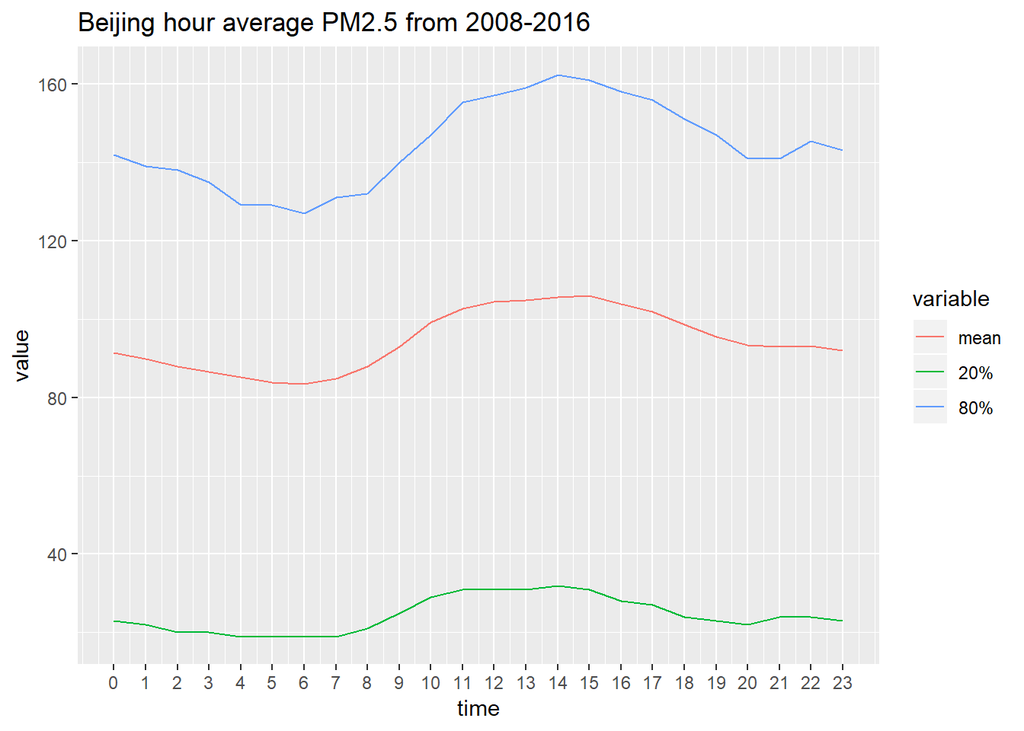

```r
ggplot(data = dt,mapping = aes(x=time,y=value,color = variable))+geom_line()+
  scale_x_continuous(breaks = 0:23)+ggtitle("Beijing hour average PM2.5 from 2008-2016")
```

Are there any daily or monthly trends? We can start the data interrogation by building an ARIMA model and examining detailed patterns in the data.

## 1.1 Step 1: Plot time series

To begin with, we can visualize the overall trend by plotting PM2.5 values against time. This can be achieved using the `plyr` package.

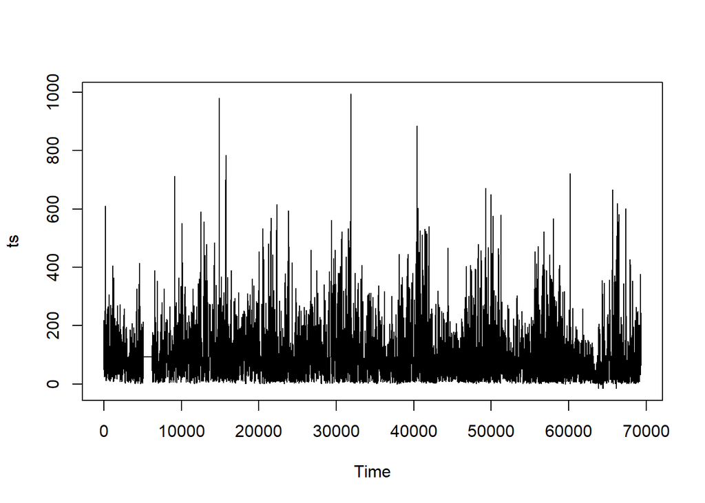

```r
library(plyr)
ts<-ts(beijing.pm25$Value, start=1, end=69335, frequency=1)
ts.plot(ts)
```

The dataset is recorded hourly and the eight-year time interval includes about $69,335$ hours of records. Therefore, we start at the first hour and end with $69,335^{th}$ hour. Each hour has a univariate [PM2.5 AQI value measurement](https://airnow.gov/index.cfm?action=resources.conc_aqi_calc), so `frequency=1`.

From this time series plot, we observe that the data has some peaks but most of the AQIs stay under 300 (which is consider hazardous).

The original plot seems have no trend at all. Remember we have our measurements in hours. Will there be any difference if we use monthly average instead of hourly reported values? In this case, we can use Simple Moving Average (SMA) technique to smooth the original graph.

To do this we need to install `TTR` package.

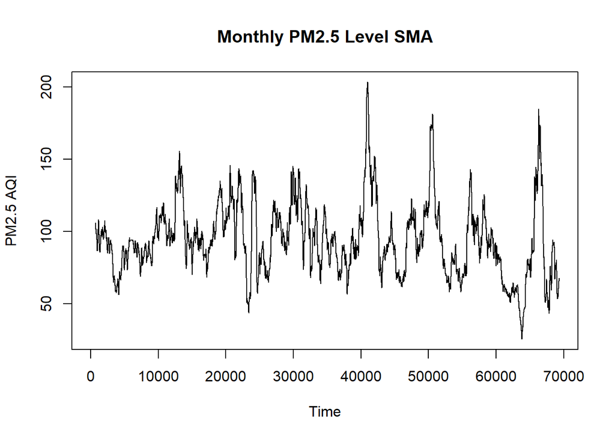

```r
# install.packages("TTR")
library(TTR)
bj.month<-SMA(ts, n=720)
plot.ts(bj.month, main="Monthly PM2.5 Level SMA", ylab="PM2.5 AQI")
```

Here we chose `n` to be $24*30=720$ and we can see some pattern. It seems that for the first 4 years (or approximately 35,040 hours) the AQI fluctuates less than the last 5 years. Let’s see what happens if we use *exponentially-weighted mean*, instead of *arithmetic mean*.

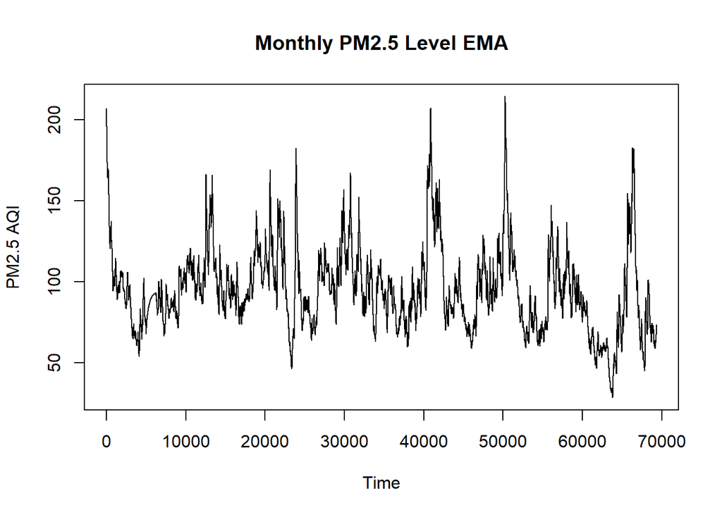

```r
bj.month<-EMA(ts, n=1, ratio = 2/(720+1))
plot.ts(bj.month, main="Monthly PM2.5 Level EMA", ylab="PM2.5 AQI")
```

The pattern seems less obvious in this graph. Here we uses exponential smoothing ratio of $2/(n+1)$.

## 1.2 Step 2: Find proper parameter values for ARIMA model

ARIMA models have 2 components – autoregressive part (AR) and moving average part (MA). An $ARMA(p, d, q)$ model is a model with *p* terms in AR and *q* terms in MA, and *d* representing the order difference. Where differencing is used to make the original dataset approximately stationary. If we denote by $L$ the *lag operator*, by $\phi_i$ the parameters of the autoregressive part of the model, by $\theta_i$ the parameters of the moving average part, and by $\epsilon_t$ error terms, then the $ARMA(p, d, q)$ has the following analytical form:

$$(1-\sum_{i=1}^p\phi_i L^i)(1-L)^d X_t=(1+\sum_{i=1}^q\theta_i L^i)\epsilon_t .$$

## 1.3 Check the differencing parameter

First, let’s try to determine the parameter *d*. To make the data stationary on the mean (remove any trend), we can use first differencing or second order differencing. Mathematically, first differencing is taking the difference between two adjacent data points:
$$y_t'=y_t-y_{t-1}.$$
While second order differencing is differencing the data twice:
$$y_t^*=y_t'-y_{t-1}'=y_t-2y_{t-1}+y_{t-2}.$$
Let’s see which differencing method is proper for the Beijing PM2.5 dataset. Function `diff()` in R base can be used to calculate differencing. We can plot the differences by `plot.ts()`.

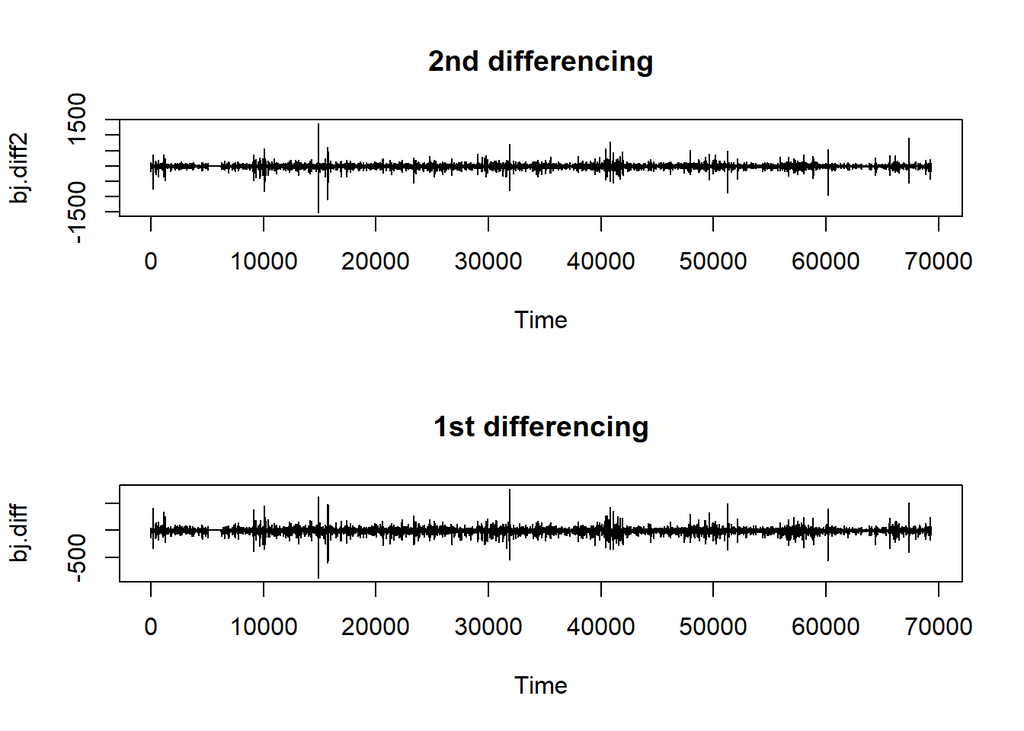

```r
par(mfrow= c(2, 1))
bj.diff2<-diff(ts, differences=2)
plot.ts(bj.diff2, main="2nd differencing")
bj.diff<-diff(ts, differences=1)
plot.ts(bj.diff, main="1st differencing")
```

Neither of them appears quite stationary. In this case, we can consider using some smoothing techniques on the data like we just did above (`bj.month<-SMA(ts, n=720)`). Let’s see if smoothing by exponentially-weighted mean (EMA) can help making the data approximately stationary.

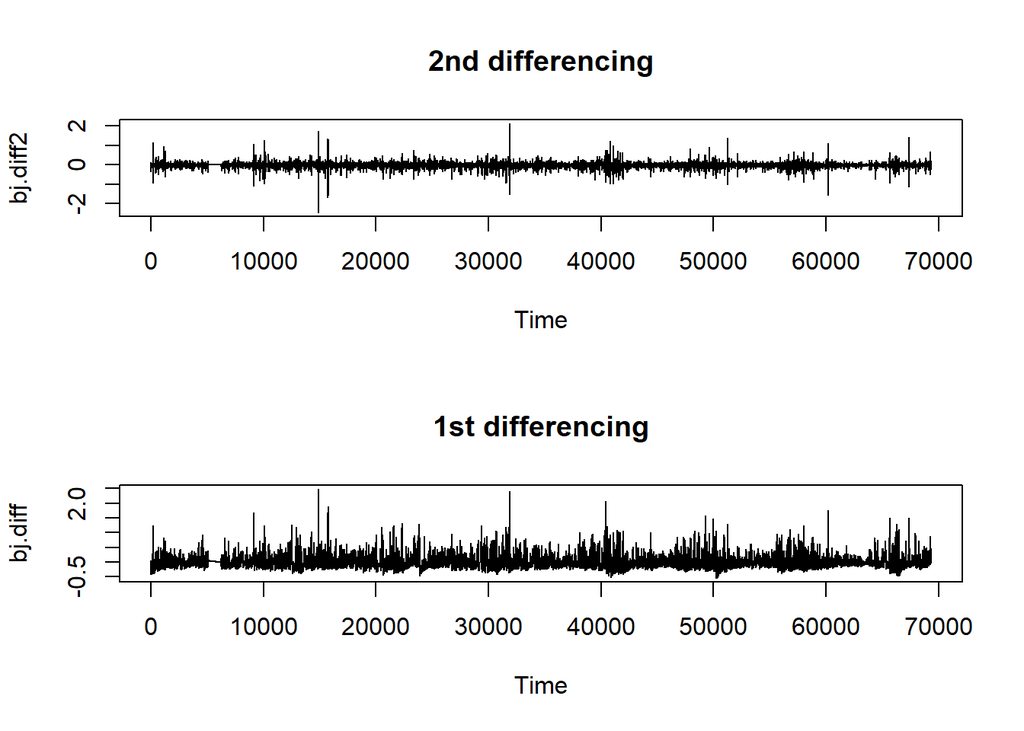

```r
par(mfrow=c(2, 1))
bj.diff2<-diff(bj.month, differences=2)
plot.ts(bj.diff2, main="2nd differencing")
bj.diff<-diff(bj.month, differences=1)
plot.ts(bj.diff, main="1st differencing")
```

Both of these EMA-filtered graphs have tempered variance and appear pretty stationary with respect to the first two moments, mean and variance.

## 1.4 Identifying the AR and MA parameters

To decide the auto-regressive (AR) and moving average (MA) parameters in the model we need to create **autocorrelation factor (ACF)** and **partial autocorrelation factor (PACF) plots**. PACF may suggest a value for the AR-term parameter $p$, and ACF may help us determine the MA-term parameter $q$. We plot the ACF and PACF, we use approximately stationary time series `bj.diff` objects.

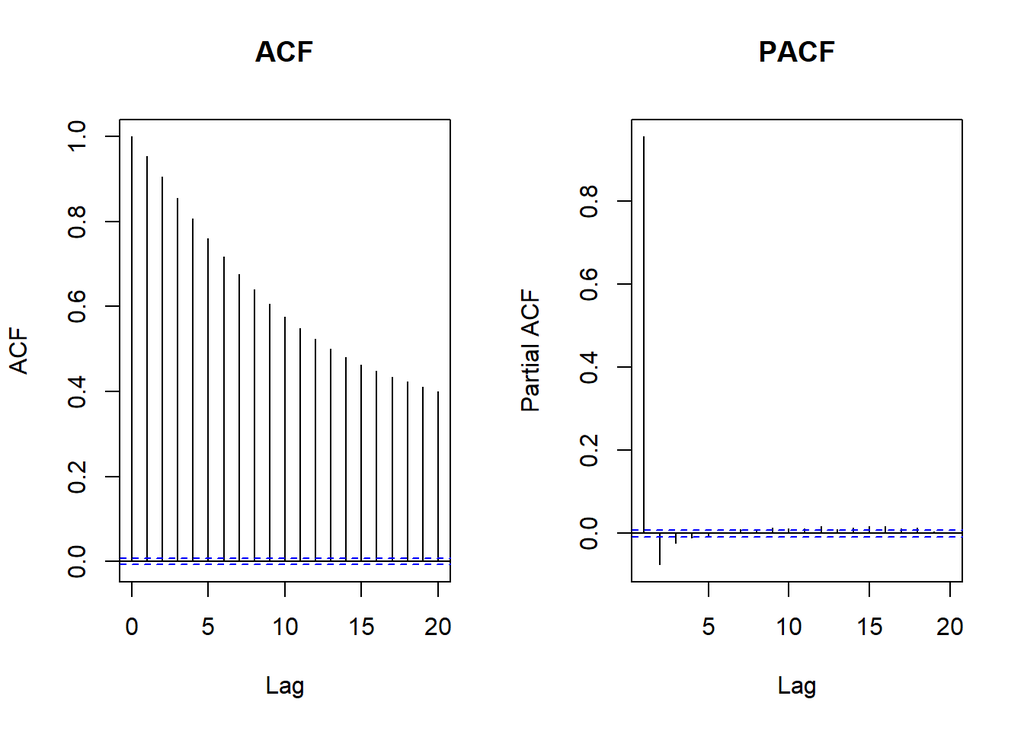

```r
par(mfrow=c(1, 2))
acf(ts(bj.diff), lag.max = 20, main="ACF")
pacf(ts(bj.diff), lag.max = 20, main="PACF")
```

All spikes in the plots are outside of insignificant zone in the ACF plot while 2 of them are significant in the PACF plot. In this case, the best ARIMA model is likely to have both AR and MA parts.

We can examine for seasonal effects in the data using `stats::stl()`, a flexible function for decomposing and forecasting the series, which uses averaging to calculate the seasonal component of the series and then subtracts the seasonality. Decomposing the series and removing the seasonality can be done by subtracting the seasonal component from the original series using `forecast::seasadj()`. The frequency parameter in the `ts()` object specifies the periodicity of the data or the number of observations per period, e.g., 30 (for monthly smoothed daily data).

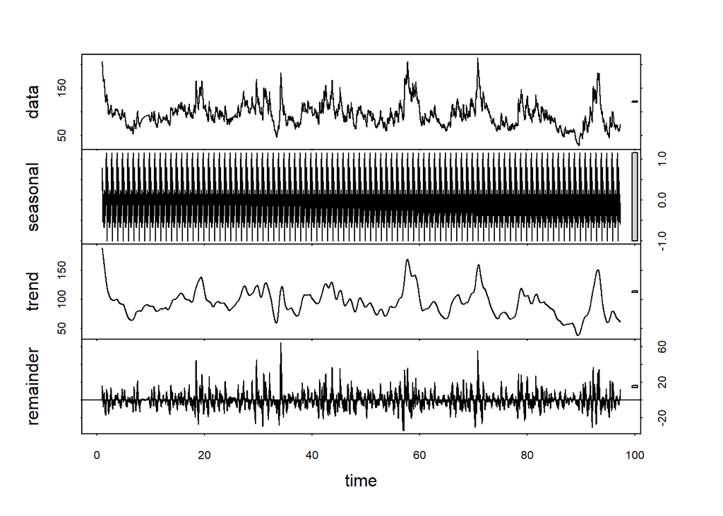

```r
count_ma = ts(bj.month, frequency=30*24)
decomp = stl(count_ma, s.window="periodic")
deseasonal_count <- forecast::seasadj(decomp)
plot(decomp)
```

The augmented Dickey-Fuller (ADF) test, `tseries::adf.test` can be used to examine the time series stationarity. The *null hypothesis is that the series is non-stationary*. The ADF test quantifies if the change in the series can be explained by a lagged value and a linear trend. Non-stationary series can be *corrected* by differencing to remove trends or cycles.

```r
tseries::adf.test(count_ma, alternative = "stationary")
```

```
##
##  Augmented Dickey-Fuller Test
##
## data:  count_ma
## Dickey-Fuller = -8.0313, Lag order = 41, p-value = 0.01
## alternative hypothesis: stationary
```

```r
tseries::adf.test(bj.diff, alternative = "stationary")
```

```
##
##  Augmented Dickey-Fuller Test
##
## data:  bj.diff
## Dickey-Fuller = -29.188, Lag order = 41, p-value = 0.01
## alternative hypothesis: stationary
```

We see that we can reject the null and therefore, there is no statistically significant non-stationarity in the `bj.diff` time series.

## 1.5 Step 3: Build an ARIMA model

As we have some evidence suggesting *d=1*, the `auto.arima()` function in the `forecast` package can help us to find the optimal estimates for the remaining pair parameters of the ARIMA model, *p* and *q*.

```r
# install.packages("forecast")
library(forecast)
fit<-auto.arima(bj.month, approx=F, trace = F)
fit
```

```
## Series: bj.month
## ARIMA(1,1,4)
##
## Coefficients:
##          ar1     ma1     ma2     ma3     ma4
##       0.9426  0.0813  0.0323  0.0156  0.0074
## s.e.  0.0016  0.0041  0.0041  0.0041  0.0041
##
## sigma^2 estimated as 0.004604:  log likelihood=88161.91
## AIC=-176311.8   AICc=-176311.8   BIC=-176257
```

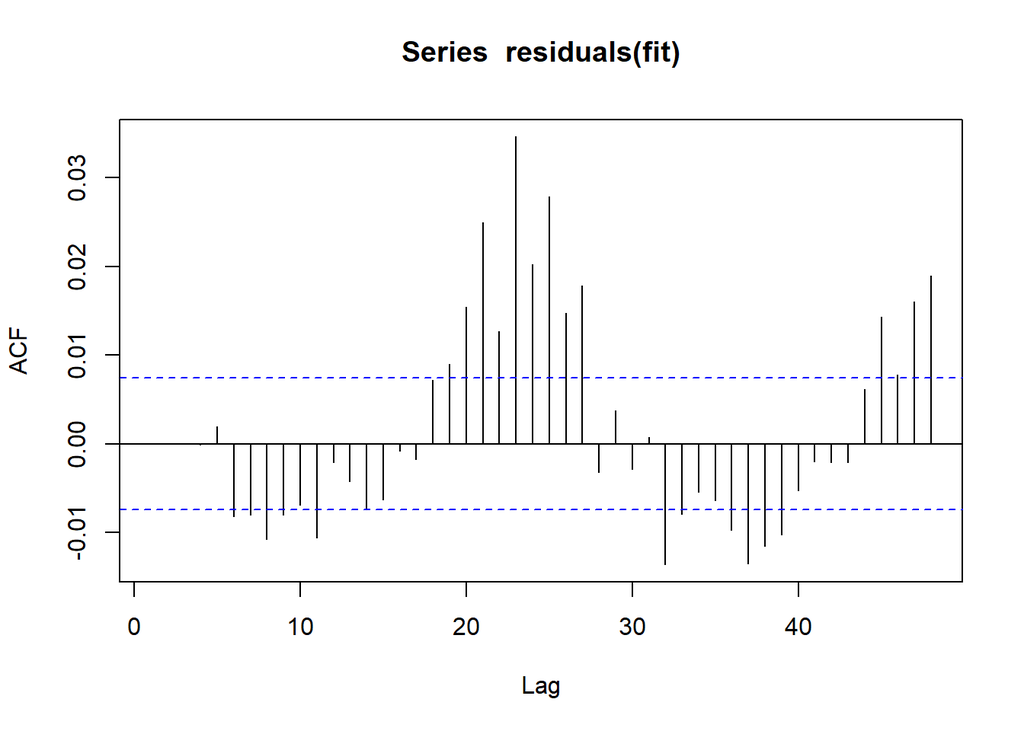

```r
Acf(residuals(fit))
```

Finally, the optimal model determined by the step-wise selection is `ARIMA(1, 1, 4)`.

We can also use external information to fit ARIMA models. For example, if we want to add the month information, in case we suspect a seasonal change in PM2.5 AQI, we can use the following script.

```r
fit1<-auto.arima(bj.month, xreg=beijing.pm25$Month, approx=F, trace = F)
fit1
```

```
## Series: bj.month
## Regression with ARIMA(1,1,4) errors
##
## Coefficients:
##          ar1     ma1     ma2     ma3     ma4     xreg
##       0.9427  0.0813  0.0322  0.0156  0.0075  -0.0021
## s.e.  0.0016  0.0041  0.0041  0.0041  0.0041   0.0015
##
## sigma^2 estimated as 0.004604:  log likelihood=88162.9
## AIC=-176311.8   AICc=-176311.8   BIC=-176247.8
```

```r
fit3<-arima(bj.month, order = c(2, 1, 0))
fit3
```

```
##
## Call:
## arima(x = bj.month, order = c(2, 1, 0))
##
## Coefficients:
##          ar1      ar2
##       1.0260  -0.0747
## s.e.  0.0038   0.0038
##
## sigma^2 estimated as 0.004606:  log likelihood = 88138.32,  aic = -176270.6
```

We want the model AIC and BIC to be as small as possible. This model is actually worse than the last model without `Month` predictor in terms of AIC and BIC. Also, the coefficient is very small and not significant (according to the t-test). Thus, we can remove the `Month` term.

We can examine further the ACF and the PACF plots and the residuals to determine the model quality. When the model order parameters and structure are correctly specified, we expect no significant autocorrelations present in the model residual plots.

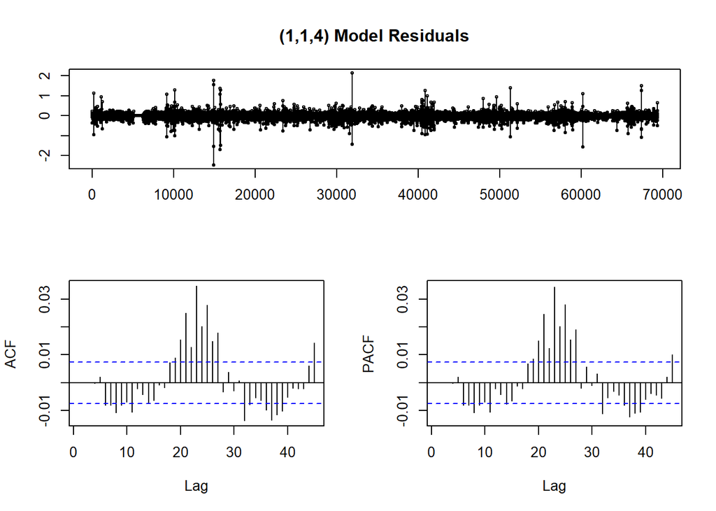

```r
tsdisplay(residuals(fit), lag.max=45, main='(1,1,4) Model Residuals')
```

There is a clear pattern present in ACF/PACF plots suggesting that the model residuals repeat with an approximate lag of 12 or 24 months. We may try a modified model with a different parameters, e.g., $p = 24$ or $q = 24$. We can define a new `displayForecastErrors()` function to show a histogram of the forecasted errors.

```r
fit24 <- arima(deseasonal_count, order=c(1,1,24)); fit24
```

```
##
## Call:
## arima(x = deseasonal_count, order = c(1, 1, 24))
##
## Coefficients:
##          ar1     ma1     ma2     ma3      ma4      ma5      ma6      ma7
##       0.9502  0.0499  0.0163  0.0020  -0.0034  -0.0058  -0.0140  -0.0119
## s.e.  0.0032  0.0049  0.0049  0.0048   0.0047   0.0046   0.0045   0.0044
##           ma8      ma9     ma10     ma11     ma12     ma13     ma14
##       -0.0130  -0.0096  -0.0087  -0.0124  -0.0040  -0.0048  -0.0064
## s.e.   0.0044   0.0043   0.0042   0.0042   0.0041   0.0041   0.0041
##          ma15    ma16    ma17    ma18    ma19    ma20    ma21    ma22
##       -0.0041  0.0016  0.0008  0.0088  0.0092  0.0144  0.0215  0.0074
## s.e.   0.0041  0.0041  0.0041  0.0041  0.0040  0.0040  0.0040  0.0040
##         ma23    ma24
##       0.0256  0.0101
## s.e.  0.0040  0.0039
##
## sigma^2 estimated as 0.004645:  log likelihood = 87848.51,  aic = -175645
```

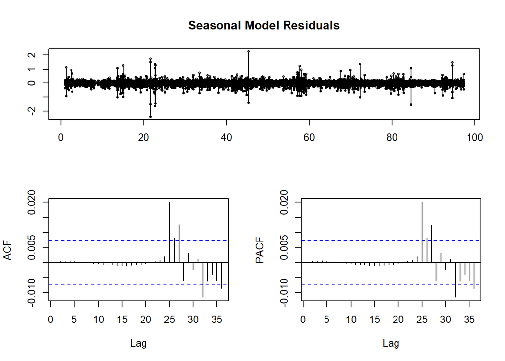

```r
tsdisplay(residuals(fit24), lag.max=36, main='Seasonal Model Residuals')
```

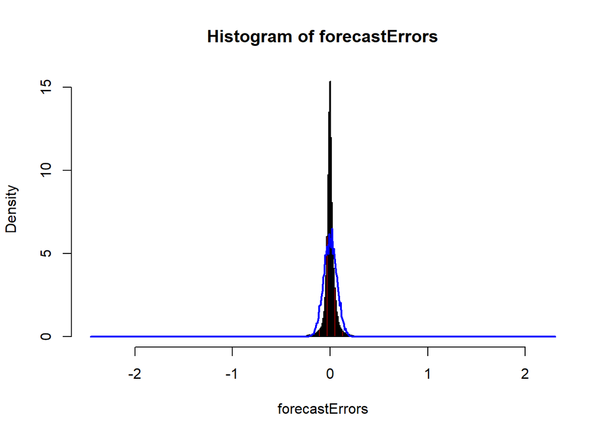

```r
displayForecastErrors <- function(forecastErrors)
  {
     # Generate a histogram of the Forecast Errors
     binsize <- IQR(forecastErrors)/4
     sd   <- sd(forecastErrors)
     min  <- min(forecastErrors) - sd
     max  <- max(forecastErrors) + sd

     # Generate 5K normal(0,sd) RVs
     norm <- rnorm(5000, mean=0, sd=sd)
     min2 <- min(norm)
     max2 <- max(norm)
     if (min2 < min) { min <- min2 }
     if (max2 > max) { max <- max2 }

     # Plot red histogram of the forecast errors
     bins <- seq(min, max, binsize)
     hist(forecastErrors, col="red", freq=FALSE, breaks=bins)

     myHist <- hist(norm, plot=FALSE, breaks=bins)

     # Overlay the Blue normal curve on top of forecastErrors histogram
     points(myHist$mids, myHist$density, type="l", col="blue", lwd=2)
}

displayForecastErrors(residuals(fit24))
```

## 1.6 Step 4: Forecasting with ARIMA model

Now, we can use our models to make predictions for future PM2.5 AQI. We will use the function `forecast()` to make predictions. In this function, we have to specify the number of periods we want to forecast. Note that the data has been smoothed. Let’s make predictions for the next month or July 2016. Then there are $24\times30=720$ hours, so we specify a horizon `h=720`.

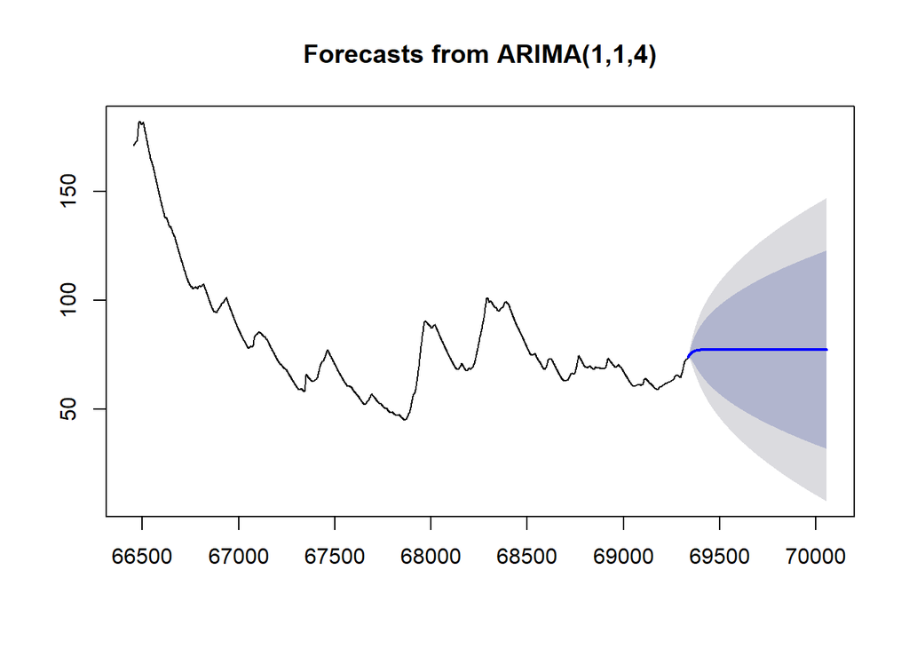

```r
par(mfrow=c(1, 1))
ts.forecasts<-forecast(fit, h=720)
plot(ts.forecasts, include = 2880)
```

## 1.7 Autoregressive Integrated Moving Average *Extended/Exogenous* (ARIMAX) Model

The [classical ARIMA model](https://books.google.com/books?hl=en&lr=&id=rNt5CgAAQBAJ) makes prediction of a univariate outcome based only on the past values of the specific forecast variable. It assumes that future values of the outcome linearly depend on an additive representation of the effects of it previous values and some stochastic components.

The [extended, or exogeneous feature, (vector-based) time-series model (ARIMAX)](https://books.google.com/books?hl=en&lr=&id=ZCmFI5U1j6cC) allows forecasting of the univariate outcome based on multiple independent (predictor) variables. Similarly to going from simple linear regression to multivariate linear models, ARIMAX generalizes the ARIMA model accounting for autocorrelation present in residuals of the linear regression to improve the accuracy of a time-series forecast. ARIMAX models, also called dynamic regression models, represent a combination of ARIMA, regression, and single-input-single-output transfer function models.

When there are no covariates, traditional time-series $y_1, y_2, \dots,y_n$ can be modeled by ARMA$(p,q)$ model:

$$y_t = \phi_1 y_{t-1} + \phi_2 y_{t-2} + \cdots + \phi_p y_{t-p} - \left ( \theta_1 \epsilon_{t-1} + \theta_2 \epsilon_{t-2} + \dots + \theta_q \epsilon_{t-q}\right ) + \epsilon_t,$$

where $\epsilon_t \sim N(0,1)$ is a white Gaussian noise.

The extended dynamic time-series model, ARIMAX, adds the covariates to the right hand side:

$$y_t = \left ( \displaystyle\sum_{k=1}^K{\beta_k x_{k,t}}\right ) + \phi_1 y_{t-1} + \phi_2 y_{t-2} + \cdots + \phi_p y_{t-p} - \left ( \theta_1 \epsilon_{t-1} + \theta_2 \epsilon_{t-2} + \dots + \theta_q z_{t-q}\right ) + \epsilon_t,$$
where $x_{k,t}$ is the value of the $k^{th}$ covariate at time $t$ and $\beta_k$ is its regression coefficient. In the ARIMAX models, the interpretation of the covariate coefficient, $\beta_k$, is somewhat different from the linear modeling case; $\beta_k$ does not really represent the effect of increasing $x_{k,t}$ by 1 on $y_t$. The coefficients $\beta_k$ may be interpreted as conditional effects of the predictor $x_k$ on the prior values of the response variable, $y$, as the right hand side of the equation mean includes lagged values of the response variable.

Using the short-hand back-shift operator representation, the ARMAX model is:

$$\phi(B)y_t = \left ( \displaystyle\sum_{k=1}^K{\beta_k x_{k,t}}\right ) + \theta(B)\epsilon_t.$$
Alternatively,
$$y_t = \displaystyle\sum_{k=1}^K{\left (\frac{\beta_k}{\phi(B)}x_{k,t}\right )} + \frac{\theta(B)}{\phi(B)}\epsilon_t,$$
where $\phi(B)=1-\left ( \phi_1 B + \phi_2 B\cdots + \phi_p B^p\right )$ and $\theta(B)= 1- \left (\theta_1 B + \theta_2 B \cdots + \theta_qB^q\right)$.

As the auto-regressive coefficients get mixed up with both the covariate and the error terms. To clarify these effects, we can look at the regression models with ARMA errors:

$$\begin{equation}
y_t = \displaystyle\sum_{k=1}^K{\left (\frac{\beta_k}{\phi(B)}x_{k,t}\right )} + \eta_t,\\
\eta_t = \left (\phi_1 \eta_{t-1} + \phi_2 \eta_{t-2} +\cdots + \phi_p \eta_{t-p}\right ) - \left (\theta_1 \epsilon_{t-1} + \theta_2 \epsilon_{t-2} +\dots + \theta_q z_{t-q} + \epsilon_t \right )
\end{equation}.$$

In this formulation, the regression coefficients have a more natural interpretation. Both formulations lead to the same model-based forecasting, but the second one helps with explication and interpretation of the effects.

The back-shift model formulation is:
$$y_t = \displaystyle\sum_{k=1}^K{\left (\frac{\beta_k}{\phi(B)}x_{k,t}\right )} + \frac{\theta(B)}{\phi(B)}\epsilon_t.$$

Transfer function models generalize both of these models.

$$y_t = \displaystyle\sum_{k=1}^K{\left (\frac{\beta_k(B)}{v(B)} x_{k,t}\right )} + \frac{\theta(B)}{\phi(B)}\epsilon_t.$$

It represents the lagged effects of covariates (by the $\beta_k(B)$ back-shift operator) and allows for decaying effects of covariates (by the $v(B)$ back-shift operator).

The Box-Jenkins method for selecting the orders of a transfer function model is often challenging in practice. An alternative order-selection protocol is presented in the [Hyndman’s 1998 forecasting textbook](https://robjhyndman.com/forecasting/).

To estimate the ARIMA errors when dealing with non-stationary data, we can replace $\phi(B)$ with $\nabla^d\phi(B)$, where $\nabla=(1-B)$ is the differencing operator. This accomplishes both differencing in $y_t$ and $x_t$ prior to fitting ARIMA models with errors. For model consistency and to avoid spurious regression effects, we do need to difference all variables before we estimate models with non-stationary errors.

There are alternative R functions to implement ARIMAX models, e.g., `forecast::arima()`, `forecast::Arima()`, and `forecast::auto.arima()` fit extended ARIMA models with multiple covariates and error terms. Remember that there are differences in the signs of the moving average coefficients between the alternative model parameterization formulations. Also, the `TSA::arimax()` function fits the *transfer function model*, not the ARIMAX model.

Let’s look at one ARIMAX simulated example.

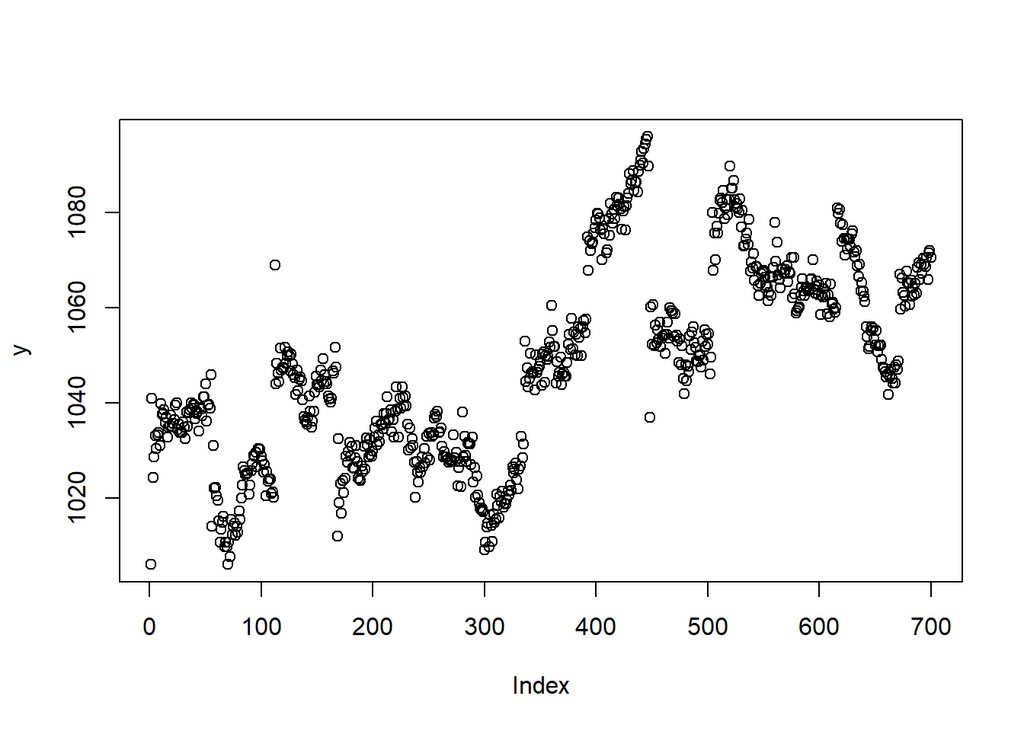

```r
library(forecast)

# create the 4D synthetic data, t=700 days, 100 weeks,
# Y=eventArrivals, X=(weekday, NewYearsHoliday, day)
weeks <- 100
days <- 7*weeks

# define holiday effect (e.g., more customers go to stores to shop)
holidayShopping <- rep(0, days)
y <- rep(0, days)
for (i in 1:days) {
  # Binary feature: Holiday
  if (i %% 28 == 0) holidayShopping[i] = 1
  else holidayShopping[i] = 0
  # Outcome (Y)
  if (i %% 56 == 0) y[i] = rpois(n=1, lambda=1500)
  else y[i] = rpois(n=1, lambda=1000)
  if (i>2) y[i] = (y[i-2] + y[i-1])/2 + rnorm(n=1, mean=0, sd=3)
  if (i %% 56 == 0) y[i] = rpois(n=1, lambda=1050)
}

plot(y)
```

```r
synthData <- data.frame(eventArrivals = y, # expected number of arrivals=1000
                         weekday = rep(1:7, weeks),     # weekday idicator variable
                         NewYearsHoliday = holidayShopping, # Binary feature: Holiday
                         day=1:days)  # day indicator

# Create matrix of numeric predictors
covariatesX <- cbind(weekday = model.matrix(~as.factor(synthData$weekday)),
                     Day = synthData$day,
                     Holiday=synthData$NewYearsHoliday)
# Generate prospective covariates for external validation/prediction
pred_length <- 56
newCovX <- cbind(weekday = model.matrix(~as.factor(synthData$weekday[1:pred_length])),
                     Day = synthData$day[1:pred_length],
                     Holiday=synthData$NewYearsHoliday[1:pred_length])

# Remove the intercept
synthX_Data <- covariatesX[,-1]

# Rename columns
colnames(synthX_Data) <- c("Mon", "Tue", "Wed", "Thu", "Fri", "Sat", "Day", "Holiday")

# Response (Y) to be modeled as a time-series, weekly oscillations (7-days)
observedArrivals <- ts(synthData$eventArrivals, frequency=7)

# Estimate the ARIMAX model
fitArimaX <- auto.arima(observedArrivals, xreg=synthX_Data); fitArimaX
```

```
## Series: observedArrivals
## Regression with ARIMA(2,0,0) errors
##
## Coefficients:
##          ar1     ar2  intercept     Mon     Tue     Wed     Thu      Fri
##       0.5086  0.4480  1022.5012  0.4539  0.6118  0.0910  0.0530  -0.2954
## s.e.  0.0348  0.0349     7.8047  0.5514  0.5315  0.5925  0.5926   0.5326
##           Sat     Day  Holiday
##       -0.3964  0.0713   1.8325
## s.e.   0.6008  0.0188   0.9555
##
## sigma^2 estimated as 25.14:  log likelihood=-2117.44
## AIC=4258.88   AICc=4259.33   BIC=4313.49
```

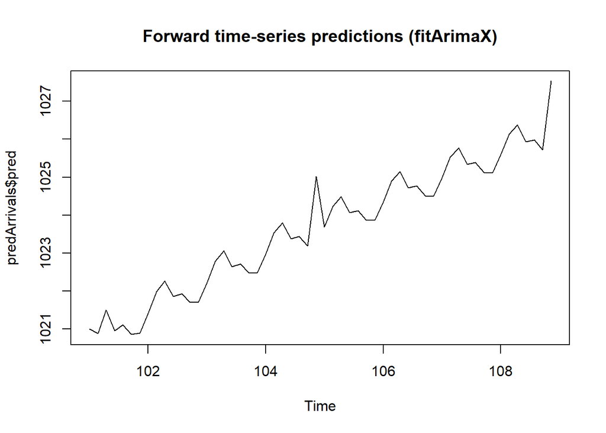

```r
# Predict prospective arrivals (e.g., volumes of customers)
predArrivals <- predict(fitArimaX, n.ahead = pred_length, newxreg = newCovX[,-1])
plot(predArrivals$pred, main="Forward time-series predictions (fitArimaX)")
```

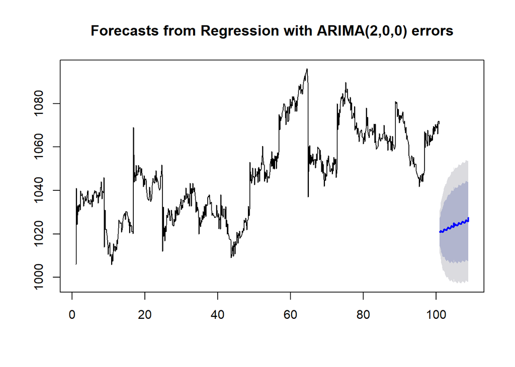

```r
plot(forecast(fitArimaX, xreg = newCovX[,-1]))
```

There are also [Vector Autoregressive Moving-Average Time Series (VARMA)](http://faculty.chicagobooth.edu/ruey.tsay/teaching/mtsbk/) models that can be used to fit multivariate linear time series for stationary processes.

## 1.8 Google Trends Analytics (Data Science)

We can use dynamic Google Trends data to retrieve information, identify temporal patters and motifs dues to various human experiences, conduct time-series analyses, and forecast future trends. If we retrieve data for multiple terms (keywords or phrases) over different periods of time and across geographic locations the problem can certainly get complex. We will utilize the R packages `gtrendsR` and `prophet`.

```r
# install.packages("prophet")
# install.packages("devtools")
# devtools::install_github("PMassicotte/gtrendsR")

library(gtrendsR)
library(ggplot2)
library(prophet)
```

Let’s search Google Trends for the volume for “data science” and “predictive analytics” searches in the US over the past ten years. Note that a time span can be specified via:

- “now 1-H”: Last hour
- “now 4-H”: Last four hours
- “now 1-d”: Last day
- “now 7-d”: Last seven days
- “today 1-m”: Past 30 days
- “today 3-m”: Past 90 days
- “today 12-m”: Past 12 months
- “today+5-y”: Last five years (default)
- “all”: Since the beginning of Google Trends (2004)
- “Y-m-d Y-m-d”: Time span between two dates (ex.: “2008-06-22 2018-06-22”)

[figure not shown]

```r
DSPA_trends_US <- gtrends(c("data science", "predictive analytics"),
                          geo = c("US"), gprop = "web",
                          time = "2008-06-22 2018-06-22")[[1]]

ggplot(data = DSPA_trends_US, aes(x = date, y = hits, group = keyword)) +
  geom_line(size = 1.5, alpha = 0.8, aes(color = keyword)) +
  geom_point(size = 1.6) +
  ylim(0, NA) +
  theme(legend.title=element_blank(), axis.title.x = element_blank()) +
  theme(legend.position="bottom") +
  ylab("Phrase Search Freq'") +
  ggtitle("Google Trends (Data Science, Predictive Analytics): 2008-2018")
```

We can also examine global geographic trends in searches for “data science”, e.g., US, China, UK.

```r
DSPA_trends_Global <- gtrends(c("data science"),
                          geo = c("US","CN","GB"), gprop = "web",
                          time = "2008-06-22 2018-06-22")[[1]]
DSPA_trends_Global$hits[is.na(DSPA_trends_Global$hits)] <- "0"
DSPA_trends_Global$hits
```

```
##   [1] "2"   "2"   "3"   "3"   "3"   "2"   "4"   "4"   "3"   "3"   "2"
##  [12] "2"   "3"   "2"   "5"   "4"   "3"   "3"   "4"   "4"   "3"   "3"
##  [23] "3"   "3"   "2"   "3"   "4"   "3"   "3"   "3"   "4"   "3"   "3"
##  [34] "3"   "3"   "3"   "2"   "3"   "5"   "3"   "4"   "3"   "5"   "4"
##  [45] "4"   "4"   "3"   "2"   "2"   "5"   "6"   "6"   "5"   "4"   "5"
##  [56] "5"   "4"   "6"   "6"   "4"   "4"   "6"   "9"   "7"   "7"   "6"
##  [67] "10"  "8"   "7"   "9"   "8"   "7"   "8"   "11"  "14"  "11"  "11"
##  [78] "10"  "13"  "12"  "13"  "13"  "12"  "12"  "12"  "16"  "21"  "17"
##  [89] "14"  "14"  "18"  "16"  "16"  "18"  "16"  "14"  "14"  "18"  "22"
## [100] "19"  "19"  "17"  "24"  "23"  "23"  "24"  "24"  "21"  "21"  "25"
## [111] "29"  "28"  "26"  "22"  "28"  "28"  "27"  "29"  "27"  "24"  "0"
## [122] "0"   "2"   "<1"  "1"   "1"   "1"   "0"   "1"   "1"   "0"   "1"
## [133] "0"   "1"   "1"   "2"   "1"   "1"   "1"   "2"   "1"   "1"   "1"
## [144] "1"   "<1"  "0"   "1"   "2"   "1"   "1"   "1"   "1"   "1"   "1"
## [155] "2"   "2"   "0"   "1"   "1"   "1"   "1"   "<1"  "1"   "1"   "2"
```

[output cut: 18 more lines]

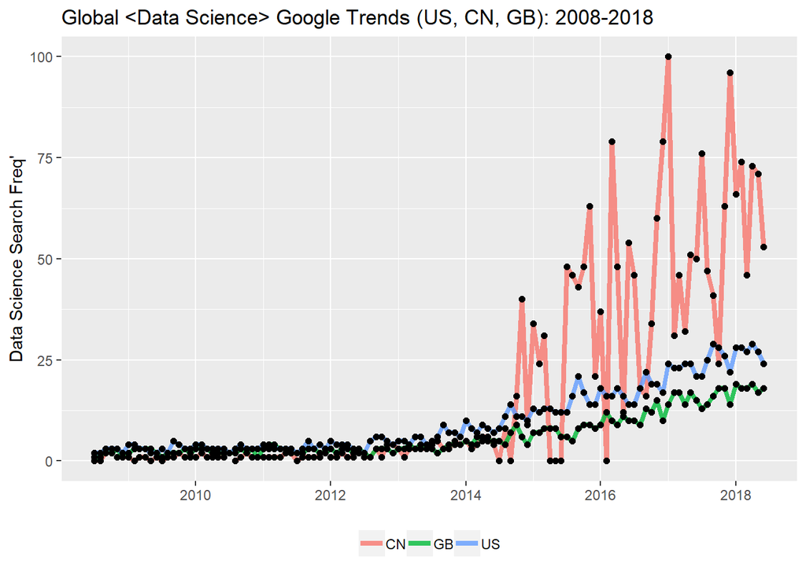

```r
ggplot(data = DSPA_trends_Global, aes(x = date,
                     y = as.numeric(hits), group = geo)) +
  geom_line(size = 1.5, alpha = 0.8, aes(color = geo)) +
  geom_point(size = 1.6) +
  ylim(0, NA) +
  theme(legend.title=element_blank(), axis.title.x = element_blank()) +
  theme(legend.position="bottom") +
  ylab("Data Science Search Freq'") +
  ggtitle("Global <Data Science> Google Trends (US, CN, GB): 2008-2018")
```

What interesting patterns, trends and behavior is evident in the plot above?

Next, we can use the `prophet` package to automatically identify patterns provide forecasts of future searches. The `prophet()` function cal requires the input data-frame () to have columns “ds” and “y” representing the time-series dates and values, respectively.

```r
US_ts <- DSPA_trends_US[ , c("date","hits")]
colnames(US_ts) <-c("ds","y")
US_ts_prophet <- prophet(US_ts)
```

```
## Initial log joint probability = -16.0551
## Optimization terminated normally:
##   Convergence detected: absolute parameter change was below tolerance
```

To generate forward looking predictions, we will use the method `predict()`.

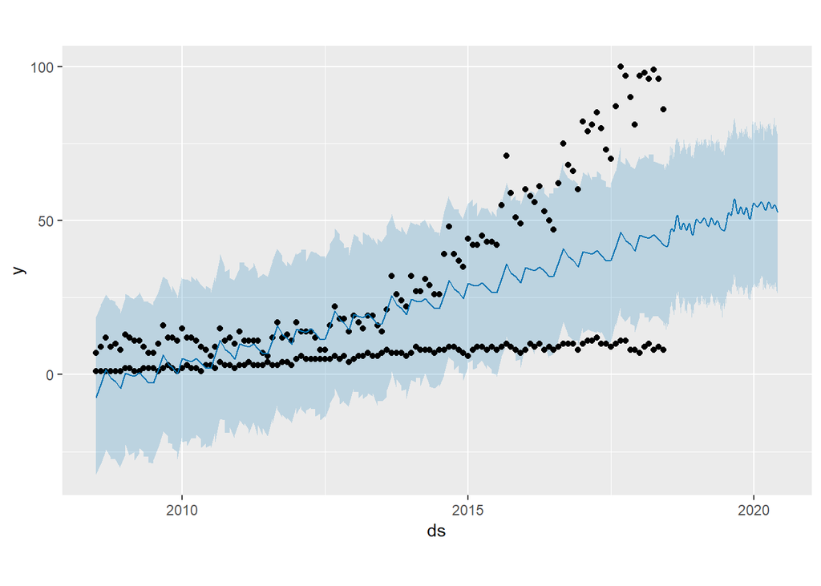

```r
future_df <- make_future_dataframe(US_ts_prophet, periods = 730)
US_ts_prophet_pred <- predict(US_ts_prophet, future_df)
plot(US_ts_prophet, US_ts_prophet_pred)
```

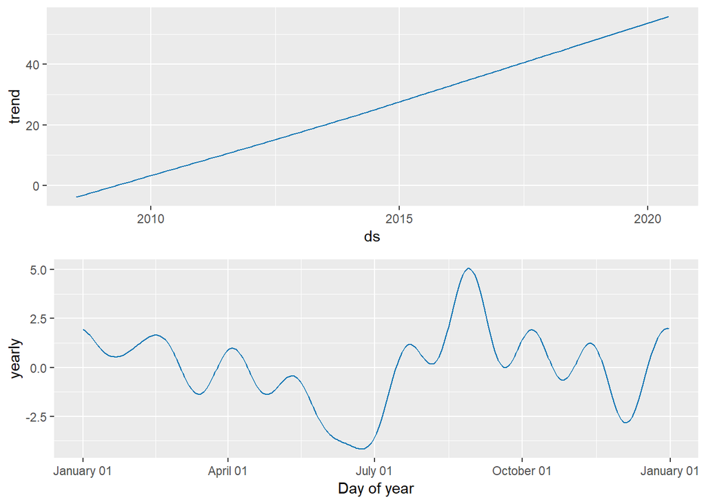

```r
prophet_plot_components(US_ts_prophet, US_ts_prophet_pred)
```

Try to fit an ARIMA time-series model to the US data.

```r
library(forecast)
fit_US_ts <- auto.arima(US_ts$y, approx=F, trace = F)
fit_US_ts
```

```
## Series: US_ts$y
## ARIMA(2,1,2)
##
## Coefficients:
##           ar1      ar2     ma1     ma2
##       -0.0059  -0.9701  0.0821  0.9381
## s.e.   0.0218   0.0188  0.0367  0.0285
##
## sigma^2 estimated as 43.56:  log likelihood=-788.78
## AIC=1587.56   AICc=1587.82   BIC=1604.94
```

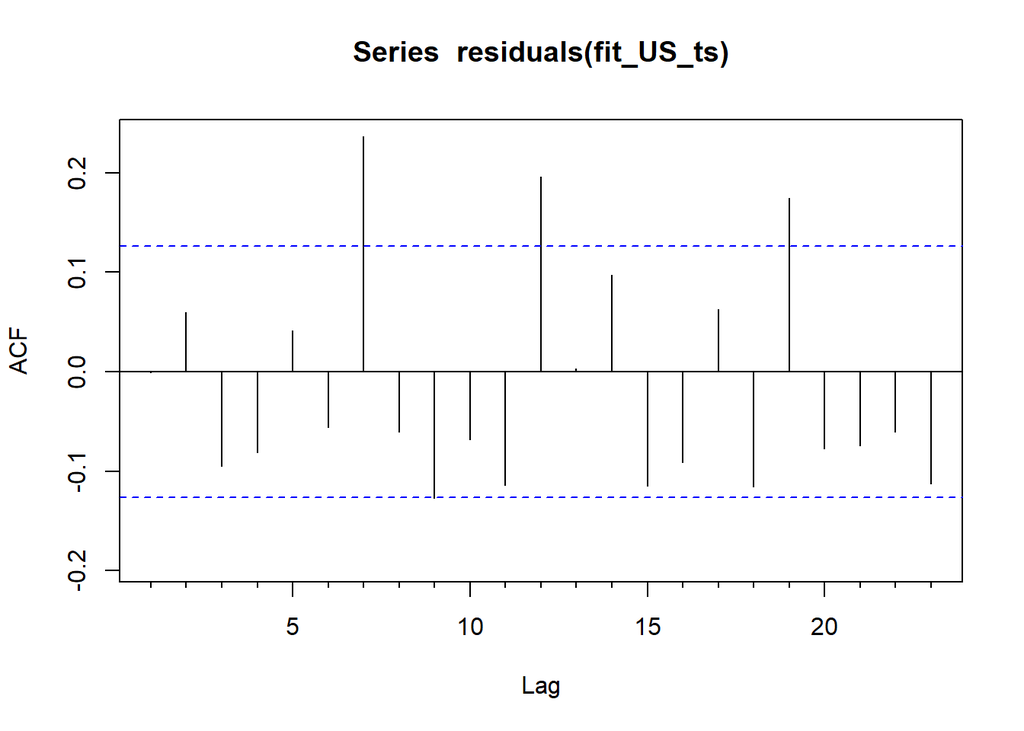

```r
Acf(residuals(fit_US_ts))
```

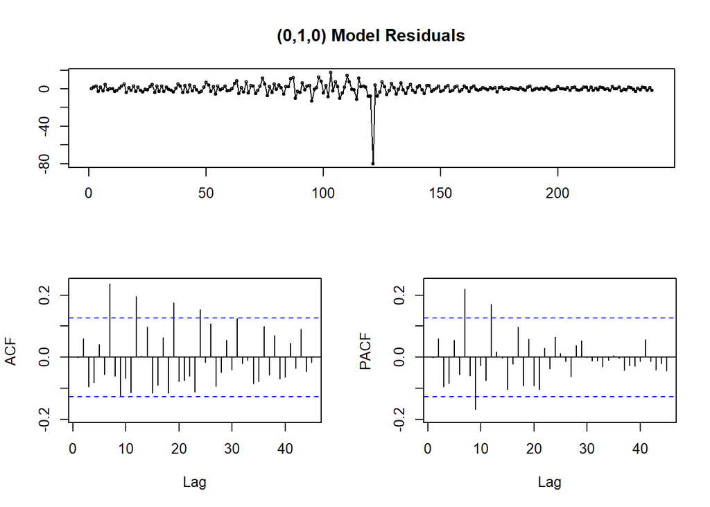

```r
tsdisplay(residuals(fit_US_ts), lag.max=45, main='(0,1,0) Model Residuals')
```

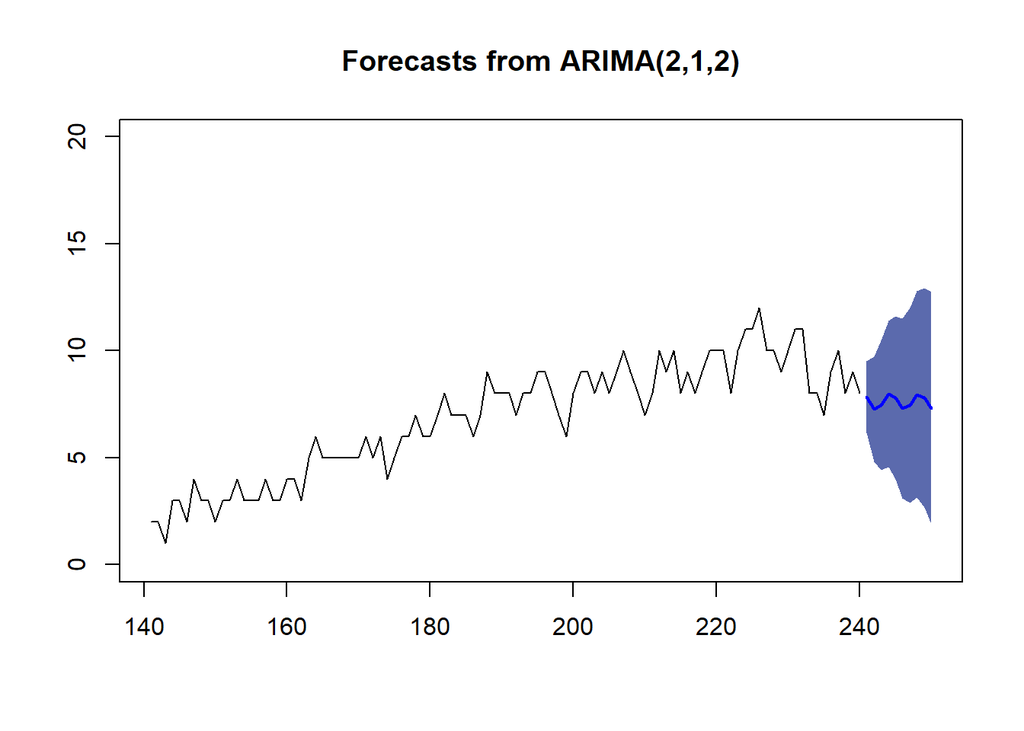

```r
fit_US_ts_forecasts <- forecast(fit_US_ts, h=10, level=20)
plot(fit_US_ts_forecasts, include = 100, ylim=c(0,20))
```

You can try to apply some of the time-series methods to the Google-Trends “hits” for some specific queries you are interested.

# 2 Structural Equation Modeling (SEM)-latent variables

The time series analysis provides an effective strategy to interrogate longitudinal univariate data. What happens if we have multiple, potentially associated, measurements recorded at each time point?

SEM is a general multivariate statistical analysis technique that can be used for causal modeling/inference, path analysis, confirmatory factor analysis (CFA), covariance structure modeling, and correlation structure modeling. This method allows *separation of observed and latent variables*. Other standard statistical procedures may be viewed as special cases of SEM, where statistical significance may be less important, and covariances are the core of structural equation models.

*Latent variables* are features that are not directly observed but may be inferred from the actually observed variables. In other words, a combination or transformation of observed variables can create latent features, which may help us reduce the dimensionality of data. Also, SEM can address multi-collinearity issues when we fit models because we can combine some high collinearity variables to create a single (latent) variable, which can then be included into the model.

## 2.1 Foundations of SEM

SEMs consist of two complementary components - a *path model*, quantifying specific cause-and-effect relationships between observed variables, and a *measurement model*, quantifying latent linkages between unobservable components and observed variables. The LISREL (LInear Structural RELations) framework represent a unifying mathematical strategy to specify these linkages, see [Grace](https://books.google.com/books?isbn=1139457845).

The most general kind of SEM is a structural regression path model with latent variables, which accounts for measurement errors of observed variables. *Model identification* determines whether the model allows for unique parameter estimates and may be based on model degrees of freedom ($df_M \geq 0$) or a known scale for every latent feature. If $\nu$ represents the number of observed variables, then the total degrees of freedom for a SEM, $\frac{\nu(1+\nu)}{2}$, corresponds to the number of variances and unique covariances in a variance-covariance matrix for all the features, and the model degrees of freedom, $df_M = \frac{\nu(1+\nu)}{2} - l$, where $l$ is the number of estimated parameters.

Examples include:

- *just-identified model* ($df_M=0$) with unique parameter estimates,
- *over-identified model* ($df_M>0$) desirable for model testing and assessment,
- *under-identified model* ($df_M<0$) is not guaranteed unique solutions for all parameters. In practice, such models occur when the effective degrees of freedom are reduced due to two or more highly-correlated features, which presents problems with parameter estimation. In these situations, we can exclude or combine some of the features boosting the degrees of freedom.

The latent variables’ *scale* property reflects their unobservable, not measurable, characteristics. The latent scale, or unit, may be inferred from one of its observed constituent variables, e.g., by imposing a unit loading identification constraint fixing at $1.0$ the factor loading of one observed variable.

An SEM model with appropriate *scale* and degrees of freedom conditions may be identifiable subject to [Bollen’s two-step identification rule](https://books.google.com/books?isbn=111861903X). When both the CFA path components of the SEM model are identifiable, then the whole SR model is identified, and model fitting can be initiated.

- For the confirmatory factor analysis (CFA) part of the SEM, identification requires (1) a minimum of two observed variables for each latent feature, (2) independence between measurement errors and the latent variables, and (3) independence between measurement errors.
- For the path component of the SEM, ignoring any observed variables used to measure latent variables, model identification requires: (1) errors associated with endogenous latent variables to be uncorrelated, and (2) all causal effects to be unidirectional.

The LISREL representation can be summarized by the following matrix equations:

$$\text{measurement model component}
\begin{cases}
x=\Lambda_x\xi +\delta, \\
y=\Lambda_y\eta +\epsilon
\end{cases}.$$

And

$$\text{path model component: }
\eta = B\eta +\Gamma\xi + \zeta,$$

where $x_{p\times1}$ is a vector of observed *exogenous variables* representing a linear function of $\xi_{j\times 1}$ vector of *exogenous latent variables*, $\delta_{p\times 1}$ is a *vector of measurement error*, $\Lambda_x$ is a $p\times j$ matrix of factor loadings relating $x$ to $\xi$, $y_{q\times1}$ is a vector of observed *endogenous variables*, $\eta_{k\times 1}$ is a vector of *endogenous latent variables*, $\epsilon_{q\times 1}$ is a vector of *measurement error for the endogenous variables*, and $\Lambda_y$ is a $q\times k$ matrix of factor loadings relating $y$ to $\eta$. Let’s also denote the two variance-covariance matrices, $\Theta_{\delta}(p\times p)$ and $\Theta_{\epsilon}(q\times q)$ representing the variance-covariance matrices among the measurement errors $\delta$ and $\epsilon$, respectively. The third equation describing the LISREL path model component as relationships among latent variables includes $B_{k\times k}$ a matrix of path coefficients describing the *relationships among endogenous latent variables*, $\Gamma_{k\times j}$ as a matrix of path coefficients representing the *linear effects of exogenous variables on endogenous variables*, $\zeta_{k\times 1}$ as a vector of *errors of endogenous variables*, and the corresponding two variance-covariance matrices $\Phi_{j\times j}$ of the *latent exogenous variables*, and $\Psi_{k\times k}$ of the *errors of endogenous variables*.

The basic statistic for a typical SEM implementations is based on covariance structure modeling and model fitting relies on optimizing an objective function, $\min f(\Sigma, S)$, representing the difference between the model-implied variance-covariance matrix, $\Sigma$, predicted from the causal and non-causal associations specified in the model, and the corresponding observed variance-covariance matrix $S$, which is estimated from observed data. The objective function, $f(\Sigma, S)$ can be estimated as follows, see [Shipley](https://books.google.com/books?isbn=1107442591).

- In general, causation implies correlation, suggesting that if there is a causal relationship between two variables, there must also be a systematic relationship between them. Specifying a set of theoretical causal paths, we can reconstruct the model-implied variance-covariance matrix, $\Sigma$, from total effects and unanalyzed associations. The LISREL strategy specifies the following mathematical representation:

$$\Sigma = \begin{vmatrix}
\Lambda_yA(\Gamma\Phi\Gamma'+\Psi)A'\Lambda'_y+\Theta_{\epsilon} & \Lambda_yA\Gamma\Phi\Lambda'_x \\
\Lambda_x\Phi\Gamma'A'\Lambda'_y & \Lambda_x\Phi\Lambda'_x+\Theta_{\delta}
\end{vmatrix},$$

where $A=(I-B)^{-1}$. This representation of $\Sigma$ does not involve the observed and latent exogenous and endogenous variables, $x,y,\xi,\eta$. Maximum likelihood estimation (MLE) may be used to obtain the $\Sigma$ parameters via iterative searches for a set of optimal parameters minimizing the element-wise deviations between $\Sigma$ and $S$.

The process of optimizing the objective function $f(\Sigma, S)$ can be achieved by computing the log likelihood ratio, i.e., comparing the the likelihood of a given fitted model to the likelihood of a perfectly fit model. MLE estimation requires multivariate normal distribution for the endogenous variables and Wishart distribution for the observed variance-covariance matrix, $S$.

Using MLE estimation simplifies the objective function to:
$$f(\Sigma, S) = \ln|\Sigma| +tr(S\times \Sigma^{-1}) -\ln|S| -tr(SS^{-1}),$$

where $tr()$ is the trace of a matrix. The optimization of $ f(, S) $ also requires that independent and identically distributed observations, and positive definite matrices. The iterative MLE optimization generates estimated variance-covariance matrices and path coefficients for the specified model. More details on model assessment (using Root Mean Square Error of Approximation (RMSEA) and Goodness of Fit Index) and the process of defining a priori SEM hypotheses are available in [Lam & Maguire](http://dx.doi.org/10.1155/2012/263953).

## 2.2 SEM components

The R `Lavaan` package uses the following SEM syntax to represent relationships between variables. We can follow the following table to specify `Lavaan` models:

| Formula Type | Operator | Explanation |
| --- | --- | --- |
| Latent variable definition | =~ | Is measured by |
| Regression | ~ | Is regressed on |
| (Residual) (co)variance | ~~ | Is correlated with |
| Intercept | ~1 | Intercept |

For example in R we can write the following model `model<-` `'` `# regressions`
$$y1 + y2 \sim f1 + f2 + x1 + x2$$
$$f1 \sim f2 + f3$$
$$f2 \sim f3 + x1 + x2$$
`# latent variable definitions`
$$f1 =\sim y1 + y2 + y3$$
$$f2 =\sim y4 + y5 + y6$$
$$f3 =\sim y7 + y8 + y9 + y10$$
`# variances and covariances`
$$y1 \sim\sim y1$$
$$y1 \sim\sim y2$$
$$f1 \sim\sim f2$$
`# intercepts`
$$y1 \sim 1$$
$$f1 \sim 1$$
`'`

Note that the two “$'$” symbols (in the beginning and ending of a model description) are very important in the `R`-syntax.

## 2.3 Case study - Parkinson’s Disease (PD)

Let’s use the PPMI dataset in our class file as an example to illustrate SEM model fitting.

### 2.3.1 Step 1 - collecting data

The [Parkinson’s Disease Data](http://wiki.socr.umich.edu/index.php/SOCR_Data_PD_BiomedBigMetadata) represents a realistic simulation case-study to examine associations between clinical, demographic, imaging and genetics variables for Parkinson’s disease. This is an example of Big Data for investigating important neurodegenerative disorders.

### 2.3.2 Step 2 - exploring and preparing the data

Now, we can import the dataset into R and recode the `ResearchGroup` variable into a binary variable.

```r
par(mfrow=c(1, 1))
PPMI<-read.csv("https://umich.instructure.com/files/330397/download?download_frd=1")
summary(PPMI)
```

```
##     FID_IID     L_insular_cortex_ComputeArea L_insular_cortex_Volume
##  Min.   :3001   Min.   :  50.03              Min.   :   22.63
##  1st Qu.:3272   1st Qu.:1976.88              1st Qu.: 4881.36
##  Median :3476   Median :2498.65              Median : 7236.76
##  Mean   :3534   Mean   :2255.20              Mean   : 6490.84
##  3rd Qu.:3817   3rd Qu.:2744.05              3rd Qu.: 8405.43
##  Max.   :4139   Max.   :3650.81              Max.   :13499.92
##
##  R_insular_cortex_ComputeArea R_insular_cortex_Volume
##  Min.   :  40.92              Min.   :  11.84
##  1st Qu.:1345.72              1st Qu.:2652.12
##  Median :1889.61              Median :4386.05
##  Mean   :1710.72              Mean   :3972.96
##  3rd Qu.:2115.76              3rd Qu.:5243.23
##  Max.   :2791.92              Max.   :8179.40
##
##  L_cingulate_gyrus_ComputeArea L_cingulate_gyrus_Volume
##  Min.   : 127.8                Min.   :   57.33
##  1st Qu.:2379.5                1st Qu.: 4173.55
##  Median :3654.1                Median : 8840.82
##  Mean   :3314.9                Mean   : 7949.13
##  3rd Qu.:4198.0                3rd Qu.:10673.24
##  Max.   :5944.2                Max.   :17153.19
##
##  R_cingulate_gyrus_ComputeArea R_cingulate_gyrus_Volume
##  Min.   : 104.1                Min.   :   47.67
##  1st Qu.:2311.6                1st Qu.: 4639.26
##  Median :3658.9                Median : 8926.48
##  Mean   :3277.2                Mean   : 7895.66
##  3rd Qu.:4211.6                3rd Qu.:10719.37
##  Max.   :6593.7                Max.   :19761.77
##
##  L_caudate_ComputeArea L_caudate_Volume    R_caudate_ComputeArea
##  Min.   :   1.782      Min.   :   0.1928   Min.   :   1.782
##  1st Qu.: 277.554      1st Qu.: 186.6480   1st Qu.: 439.057
##  Median : 694.179      Median : 975.1016   Median :1034.770
##  Mean   : 635.570      Mean   : 952.0420   Mean   : 869.426
##  3rd Qu.: 945.406      3rd Qu.:1519.8218   3rd Qu.:1184.463
##  Max.   :1453.506      Max.   :2746.6208   Max.   :1684.563
##
```

[output cut: 25 more lines]

```
##  Min.   :0.000    Min.   :0.0000    Min.   :0.0000      Min.   :0.0000
##  1st Qu.:0.000    1st Qu.:0.0000    1st Qu.:0.0000      1st Qu.:0.0000
##  Median :0.000    Median :0.0000    Median :0.0000      Median :0.0000
##  Mean   :0.346    Mean   :0.4265    Mean   :0.4028      Mean   :0.3791
##  3rd Qu.:1.000    3rd Qu.:1.0000    3rd Qu.:1.0000      3rd Qu.:1.0000
##  Max.   :2.000    Max.   :2.0000    Max.   :2.0000      Max.   :2.0000
##  NA's   :76       NA's   :76        NA's   :76          NA's   :76
##   UPDRS_part_I    UPDRS_part_II    UPDRS_part_III    time_visit
##  Min.   : 0.000   Min.   : 0.000   Min.   : 0.00   Min.   : 0.00
##  1st Qu.: 0.000   1st Qu.: 2.000   1st Qu.:12.00   1st Qu.: 8.25
##  Median : 1.000   Median : 5.000   Median :20.00   Median :21.00
##  Mean   : 1.286   Mean   : 6.087   Mean   :19.44   Mean   :23.50
##  3rd Qu.: 2.000   3rd Qu.: 9.000   3rd Qu.:27.00   3rd Qu.:37.50
##  Max.   :13.000   Max.   :28.000   Max.   :61.00   Max.   :54.00
##  NA's   :549      NA's   :553      NA's   :554
```

```r
PPMI$ResearchGroup<-ifelse(PPMI$ResearchGroup=="Control", "1", "0")
# PPMI <- PPMI[ , !(names(PPMI) %in% c("FID_IID", "time_visit"))] # remove Subject ID/time
```

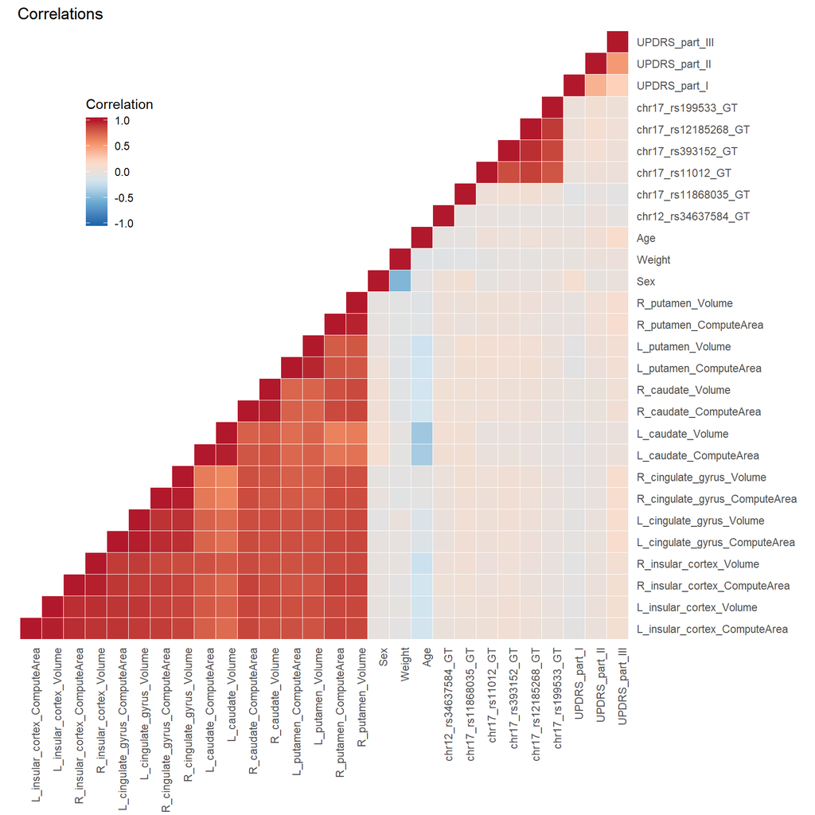

```r
pp_heat <- PPMI[complete.cases(PPMI), -c(1, 20, 31)]
corr_mat = cor(pp_heat)
# Remove upper triangle
corr_mat_lower = corr_mat
corr_mat_lower[upper.tri(corr_mat_lower)] = NA
# Melt correlation matrix and make sure order of factor variables is correct
corr_mat_melted = melt(corr_mat_lower)
colnames(corr_mat_melted) <- c("Var1", "Var2", "value")
corr_mat_melted$Var1 = factor(corr_mat_melted$Var1, levels=colnames(corr_mat))
corr_mat_melted$Var2 = factor(corr_mat_melted$Var2, levels=colnames(corr_mat))
# Plot
corr_plot = ggplot(corr_mat_melted, aes(x=Var1, y=Var2, fill=value)) +
  geom_tile(color='white') +
  scale_fill_distiller(limits=c(-1, 1), palette='RdBu', na.value='white',
                       name='Correlation') +
  ggtitle('Correlations') +
  coord_fixed(ratio=1) +
  theme_minimal() +
  scale_y_discrete(position="right") +
  theme(axis.text.x=element_text(angle=90, vjust=1, hjust=1),
        axis.title.x=element_blank(),
        axis.title.y=element_blank(),
        panel.grid.major=element_blank(),
        legend.position=c(0.1,0.9),
        legend.justification=c(0,1))
corr_plot
```

And there are some specific correlations.

```r
cor(PPMI$L_insular_cortex_ComputeArea, PPMI$L_insular_cortex_Volume)
```

```
## [1] 0.9837297
```

```r
cor(PPMI$UPDRS_part_I, PPMI$UPDRS_part_II, use = "complete.obs")
```

```
## [1] 0.4027434
```

```r
cor(PPMI$UPDRS_part_II, PPMI$UPDRS_part_III, use = "complete.obs")
```

```
## [1] 0.5326681
```

One way to solve this is to create some latent variables. We can consider the following model.

```r
model1<-
  '
    Imaging =~ L_cingulate_gyrus_ComputeArea  + L_cingulate_gyrus_Volume+R_cingulate_gyrus_ComputeArea+R_cingulate_gyrus_Volume+R_insular_cortex_ComputeArea+R_insular_cortex_Volume
    UPDRS=~UPDRS_part_I+UPDRS_part_II+UPDRS_part_III
    DemoGeno =~ Weight+Sex+Age

    ResearchGroup ~ Imaging + DemoGeno + UPDRS
  '
```

Here we try to create three latent variables-`Imaging`, `DemoGeno`, and `UPDRS`. Let’s fit a SEM model using `cfa()`(confirmatory factor analysis) function. Before fitting the data, we need to scale our dataset. However, we don’t need to scale our binary response variable. We can use the following chunk of code to do the job.

```r
mydata<-scale(PPMI[, -c(1,20,31)]) # avoid scaling ID, Dx, Time
mydata<-data.frame(PPMI$FID_IID, mydata, cbind(PPMI$time_visit, PPMI$ResearchGroup))
colnames(mydata)[1]<-"FID_IID"
colnames(mydata)[30]<-"time_visit"
colnames(mydata)[31]<-"ResearchGroup"
```

### 2.3.3 Step 3 - fitting a model on the data

Now, we can start to build the model. The `cfa()` function we will use shortly belongs to `lavaan` package.

```r
# install.packages("lavaan")
# install.packages("pbivnorm")
library(lavaan)
# lavaan requires all variables to be ordered
# mydata[,] <- lapply(mydata[,], ordered)
mydata$ResearchGroup <- as.ordered(mydata$ResearchGroup)
fit<-cfa(model1, data=mydata, missing = 'FIML')
```

```r
model2 <-
    '
# (1) Measurement Model
Imaging =~  L_cingulate_gyrus_ComputeArea  + L_cingulate_gyrus_Volume+R_cingulate_gyrus_ComputeArea+R_cingulate_gyrus_Volume+R_insular_cortex_ComputeArea+R_insular_cortex_Volume
UPDRS =~  UPDRS_part_I  +UPDRS_part_II + UPDRS_part_III
# (2) Regressions
ResearchGroup ~ Imaging + UPDRS +Age+Sex+Weight
'
```

```r
fit<-cfa(model2, data=mydata, missing = 'FIML')
```

```
## Warning in lav_options_set(opt): lavaan WARNING: information will be set to
## "expected" for estimator = "DWLS"
```

```r
summary(fit, fit.measures=TRUE)
```

```
## lavaan 0.6-2 ended normally after 43 iterations
##
##   Optimization method                           NLMINB
##   Number of free parameters                         34
##
##   Number of observations                          1764
##   Number of missing patterns                         4
##
##   Estimator                                       DWLS      Robust
##   Model Fit Test Statistic                     524.491     365.296
##   Degrees of freedom                                60          60
##   P-value (Chi-square)                           0.000       0.000
##   Scaling correction factor                                  1.599
##   Shift parameter                                           37.258
##     for simple second-order correction (Mplus variant)
##
## Model test baseline model:
##
##   Minimum Function Test Statistic             9851.634    3799.131
##   Degrees of freedom                                75          75
##   P-value                                        0.000       0.000
##
## User model versus baseline model:
##
##   Comparative Fit Index (CFI)                    0.952       0.918
##   Tucker-Lewis Index (TLI)                       0.941       0.898
##
##   Robust Comparative Fit Index (CFI)                            NA
##   Robust Tucker-Lewis Index (TLI)                               NA
##
## Root Mean Square Error of Approximation:
##
##   RMSEA                                          0.066       0.054
##   90 Percent Confidence Interval          0.061  0.072       0.048  0.059
##   P-value RMSEA <= 0.05                          0.000       0.119
##
##   Robust RMSEA                                                  NA
##   90 Percent Confidence Interval                                NA     NA
##
## Standardized Root Mean Square Residual:
```

[output cut: 59 more lines]

```
##    .L_cnglt_gyrs_V    0.042    0.003   14.404    0.000
##    .R_cnglt_gyr_CA    0.068    0.003   21.416    0.000
##    .R_cnglt_gyrs_V    0.084    0.004   23.151    0.000
##    .R_nslr_crtx_CA    0.096    0.005   19.683    0.000
##    .R_nslr_crtx_Vl    0.123    0.005   26.831    0.000
##    .UPDRS_part_I      0.571    0.013   44.059    0.000
##    .UPDRS_part_II     0.283    0.019   14.782    0.000
##    .UPDRS_part_III    0.312    0.021   14.590    0.000
##    .ResearchGroup     0.437
##     Imaging           0.966    0.044   21.731    0.000
##     UPDRS             0.108    0.010   10.438    0.000
##
## Scales y*:
##                    Estimate  Std.Err  z-value  P(>|z|)
##     ResearchGroup     1.000
```

## 2.4 Outputs of Lavaan SEM

# 3 Longitudinal data analysis-Linear Mixed model

As mentioned earlier, longitudinal studies take measurements for the same individual repeatedly through a period of time. Under this setting, we can measure the change after a specific treatment. However, the measurements for the same individual may be correlate with each other. Thus, we need special models that deal with this type of internal inter-dependencies.

If we use the latent variable UPDRS (created in the output of SEM model) rather than research group as our response we can conduct the following longitudinal analysis. In longitudinal analysis, time is often an important variable in the model.

## 3.1 Mean trend

According to the output of model `fit`, our latent variable `UPDRS` is a combination of three observed variables-`UPDRS_part_I`, `UPDRS_part_II`, and `UPDRS_part_III`. We can visualize how average `UPDRS` differ in different research groups over time.

```r
mydata$UPDRS<-mydata$UPDRS_part_I+1.890*mydata$UPDRS_part_II+2.345*mydata$UPDRS_part_III
mydata$Imaging<-mydata$L_cingulate_gyrus_ComputeArea  +0.994*mydata$L_cingulate_gyrus_Volume+0.961*mydata$R_cingulate_gyrus_ComputeArea+0.955*mydata$R_cingulate_gyrus_Volume+0.930*mydata$R_insular_cortex_ComputeArea+0.920*mydata$R_insular_cortex_Volume
```

The above chunk of code stored `UPDRS` and `Imaging` variables into `mydata`. By now, we are experienced with using the package `ggplot2` for data visualization. Now, we will use it to set the *x* and *y* axes as `time` and `UPDRS`, and then display the trend of the individual level `UPDRS`.

```r
require(ggplot2)
p<-ggplot(data=mydata, aes(x=time_visit, y=UPDRS, group=FID_IID))
dev.off()
```

```r
p+geom_point()+geom_line()
```

This graph is not shown as it is uninformative without a clear pattern emerging. Let’s see if group-level graphs may provide more intuition. We will use the `aggregate()` function to get the mean, minimum and maximum of `UPDRS` for each time point. Then, we will use separate color for the two research groups and examine their mean trends.

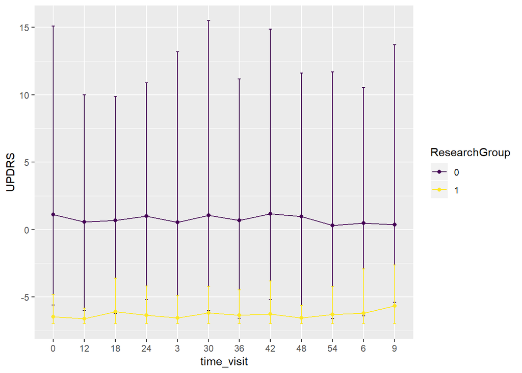

```r
ppmi.mean<-aggregate(UPDRS~time_visit+ResearchGroup, FUN = mean, data=mydata[, c(30, 31, 32)])
ppmi.min<-aggregate(UPDRS~time_visit+ResearchGroup, FUN = min, data=mydata[, c(30, 31, 32)])
ppmi.max<-aggregate(UPDRS~time_visit+ResearchGroup, FUN = max, data=mydata[, c(30, 31, 32)])
ppmi.boundary<-merge(ppmi.min, ppmi.max, by=c("time_visit", "ResearchGroup"))
ppmi.all<-merge(ppmi.mean, ppmi.boundary, by=c("time_visit", "ResearchGroup"))
pd <- position_dodge(0.1)
p1<-ggplot(data=ppmi.all, aes(x=time_visit, y=UPDRS, group=ResearchGroup, colour=ResearchGroup))
p1+geom_errorbar(aes(ymin=UPDRS.x, ymax=UPDRS.y, width=0.1))+geom_point()+geom_line()
```

Despite slight overlaps in some lines, the resulting graph illustrates better the mean differences between the two cohorts. The control group (1) appears to have relative lower means and tighter ranges compared to the PD patient group (0). However, we need further data interrogation to determine if this visual (EDA) evidence translates into statistically significant group differences.

Generally speaking we can always use the *General Linear Modeling (GLM)* framework. However, GLM may ignore the individual differences. So, we can try to fit a *Linear Mixed Model (LMM)* to incorporate different intercepts for each individual participant. Consider the following GLM:

$$UPDRS_{ij}\sim \beta_0+\beta_1*Imaging_{ij}+\beta_2*ResearchGroup_i+\beta_3*{time\_visit}_j+\beta_4*ResearchGroup_i*time\_visit_j+\beta_5*Age_i+\beta_6*Sex_i+\beta_7*Weight_i+\epsilon_{ij}$$

If we fit a different intercept for each individual (indicated by FID_IID) we obtain the following LMM model:

$$UPDRS_{ij}\sim \beta_0+\beta_1*Imaging+\beta_2*ResearchGroup+\beta_3*time_visit_j+\beta_4*ResearchGroup_i*time_visit_j+\beta_5*Age_i+\beta_6*Sex_i+\beta_7*Weight_i+b_i+\epsilon_{ij}$$

The LMM actually has two levels:

*Stage 1*
$$Y_{i}=Z_i\beta_i+\epsilon_i,$$
where both $Z_i$ and $\beta_i$ are matrices.

*Stage 2* The second level allows fitting random effects in the model.
$$\beta_i=A_i*\beta+b_i.$$
So, the full model in matrix form would be:
$$Y_i=X_i*\beta+Z_i*b_i+\epsilon_i.$$

In this case study, we only consider random intercept and avoid including random slopes, however the model can indeed be extended. In other words, $Z_i=1$ in our model. Let’s compare the two models (GLM and LMM). One R package implementing LMM is `lme4`.

```r
#install.packages("lme4")
#install.packages("arm")
library(lme4)
library(arm)
#GLM
model.glm<-glm(UPDRS~Imaging+ResearchGroup*time_visit+Age+Sex+Weight, data=mydata)
summary(model.glm)
```

```
##
## Call:
## glm(formula = UPDRS ~ Imaging + ResearchGroup * time_visit +
##     Age + Sex + Weight, data = mydata)
##
## Deviance Residuals:
##     Min       1Q   Median       3Q      Max
## -7.5395  -2.4248  -0.3399   1.8144  14.5810
##
## Coefficients:
##                               Estimate Std. Error t value Pr(>|t|)
## (Intercept)                  -2.565303   0.519533  -4.938 9.04e-07 ***
## Imaging                       0.038506   0.019088   2.017   0.0439 *
## ResearchGroup.L              -5.154534   0.735628  -7.007 4.09e-12 ***
## time_visit12                 -0.621322   0.839231  -0.740   0.4592
## time_visit18                 -0.202947   0.810294  -0.250   0.8023
## time_visit24                 -0.131717   0.734441  -0.179   0.8577
## time_visit3                  -0.433001   0.770288  -0.562   0.5741
## time_visit30                  0.162341   0.768256   0.211   0.8327
## time_visit36                 -0.355188   0.771142  -0.461   0.6452
## time_visit42                 -0.059880   0.723045  -0.083   0.9340
## time_visit48                  0.064109   0.913523   0.070   0.9441
## time_visit54                 -0.449075   0.740972  -0.606   0.5446
## time_visit6                  -0.192057   0.914179  -0.210   0.8336
## time_visit9                  -0.007355   0.813611  -0.009   0.9928
## Age                           0.559043   0.109960   5.084 4.29e-07 ***
## Sex                           0.141882   0.121838   1.165   0.2444
## Weight                        0.187597   0.119023   1.576   0.1153
## ResearchGroup.L:time_visit12 -0.163807   1.186365  -0.138   0.8902
## ResearchGroup.L:time_visit18  0.357867   1.148188   0.312   0.7553
## ResearchGroup.L:time_visit24 -0.004843   1.038613  -0.005   0.9963
## ResearchGroup.L:time_visit3   0.217065   1.089697   0.199   0.8421
## ResearchGroup.L:time_visit30  0.263696   1.087516   0.242   0.8085
## ResearchGroup.L:time_visit36  0.092552   1.090211   0.085   0.9324
## ResearchGroup.L:time_visit42 -0.141807   1.022389  -0.139   0.8897
## ResearchGroup.L:time_visit48  0.257921   1.291707   0.200   0.8418
## ResearchGroup.L:time_visit54  0.548708   1.048859   0.523   0.6010
## ResearchGroup.L:time_visit6   0.647938   1.291700   0.502   0.6160
## ResearchGroup.L:time_visit9   1.048540   1.150483   0.911   0.3623
## ---
## Signif. codes:  0 '***' 0.001 '**' 0.01 '*' 0.05 '.' 0.1 ' ' 1
##
## (Dispersion parameter for gaussian family taken to be 12.71086)
##
##     Null deviance: 21049  on 1205  degrees of freedom
## Residual deviance: 14973  on 1178  degrees of freedom
##   (558 observations deleted due to missingness)
## AIC: 6518.4
##
## Number of Fisher Scoring iterations: 2
```

```r
#LMM
model.lmm<-lmer(UPDRS~Imaging+ResearchGroup*time_visit+Age+Sex+Weight+(1|FID_IID), data=mydata)
summary(model.lmm)
```

```
## Linear mixed model fit by REML ['lmerMod']
## Formula:
## UPDRS ~ Imaging + ResearchGroup * time_visit + Age + Sex + Weight +
##     (1 | FID_IID)
##    Data: mydata
##
## REML criterion at convergence: 5718.2
##
## Scaled residuals:
##     Min      1Q  Median      3Q     Max
## -2.9717 -0.4601 -0.0633  0.3717  4.4258
##
## Random effects:
##  Groups   Name        Variance Std.Dev.
##  FID_IID  (Intercept) 8.006    2.830
##  Residual             3.420    1.849
## Number of obs: 1206, groups:  FID_IID, 440
##
## Fixed effects:
##                               Estimate Std. Error t value
## (Intercept)                  -2.594973   0.488359  -5.314
## Imaging                       0.044803   0.027173   1.649
## ResearchGroup.L              -5.134336   0.693118  -7.408
## time_visit12                 -0.574269   0.794207  -0.723
## time_visit18                 -0.190170   0.765051  -0.249
## time_visit24                 -0.153568   0.660516  -0.232
## time_visit3                  -0.388138   0.725876  -0.535
## time_visit30                  0.209954   0.724471   0.290
## time_visit36                 -0.367703   0.728561  -0.505
## time_visit42                 -0.042175   0.648509  -0.065
## time_visit48                  0.007186   0.863906   0.008
## time_visit54                 -0.442777   0.697725  -0.635
## time_visit6                  -0.078905   0.865665  -0.091
## time_visit9                   0.104821   0.738342   0.142
## Age                           0.499350   0.155383   3.214
## Sex                           0.157721   0.177683   0.888
## Weight                        0.213770   0.175261   1.220
## ResearchGroup.L:time_visit12 -0.126777   1.122606  -0.113
## ResearchGroup.L:time_visit18  0.346516   1.087360   0.319
## ResearchGroup.L:time_visit24  0.069285   0.934030   0.074
## ResearchGroup.L:time_visit3   0.181587   1.029575   0.176
## ResearchGroup.L:time_visit30  0.176013   1.027925   0.171
## ResearchGroup.L:time_visit36  0.187492   1.029518   0.182
## ResearchGroup.L:time_visit42 -0.119764   0.917032  -0.131
## ResearchGroup.L:time_visit48  0.282953   1.221584   0.232
## ResearchGroup.L:time_visit54  0.542631   0.989192   0.549
## ResearchGroup.L:time_visit6   0.539723   1.223014   0.441
## ResearchGroup.L:time_visit9   0.914618   1.044086   0.876
```

```r
display(model.lmm)
```

```
## lmer(formula = UPDRS ~ Imaging + ResearchGroup * time_visit +
##     Age + Sex + Weight + (1 | FID_IID), data = mydata)
##                              coef.est coef.se
## (Intercept)                  -2.59     0.49
## Imaging                       0.04     0.03
## ResearchGroup.L              -5.13     0.69
## time_visit12                 -0.57     0.79
## time_visit18                 -0.19     0.77
## time_visit24                 -0.15     0.66
## time_visit3                  -0.39     0.73
## time_visit30                  0.21     0.72
## time_visit36                 -0.37     0.73
## time_visit42                 -0.04     0.65
## time_visit48                  0.01     0.86
## time_visit54                 -0.44     0.70
## time_visit6                  -0.08     0.87
## time_visit9                   0.10     0.74
## Age                           0.50     0.16
## Sex                           0.16     0.18
## Weight                        0.21     0.18
## ResearchGroup.L:time_visit12 -0.13     1.12
## ResearchGroup.L:time_visit18  0.35     1.09
## ResearchGroup.L:time_visit24  0.07     0.93
## ResearchGroup.L:time_visit3   0.18     1.03
## ResearchGroup.L:time_visit30  0.18     1.03
## ResearchGroup.L:time_visit36  0.19     1.03
## ResearchGroup.L:time_visit42 -0.12     0.92
## ResearchGroup.L:time_visit48  0.28     1.22
## ResearchGroup.L:time_visit54  0.54     0.99
## ResearchGroup.L:time_visit6   0.54     1.22
## ResearchGroup.L:time_visit9   0.91     1.04
##
## Error terms:
##  Groups   Name        Std.Dev.
##  FID_IID  (Intercept) 2.83
##  Residual             1.85
## ---
## number of obs: 1206, groups: FID_IID, 440
## AIC = 5778.2, DIC = 5705.8
## deviance = 5712.0
```

Note that we use the notation `ResearchGroup*time_visit` that is same as `ResearchGroup+time_visit+ResearchGroup*time_visit` where R will include both terms and their interaction into the model. According to the model outputs, the LMM model has a relatively smaller AIC. In terms of AIC, LMM may represent a better model fit than GLM.

## 3.2 Modeling the correlation

- **Independence**: no correlation.
  $$\left(\begin{array}{ccc}
  1 & 0 &0\\
  0 & 1 &0\\
  0&0&1
  \end{array}\right)$$
- **Exchangeable**: correlations are constant across measurements.

$$\left(\begin{array}{ccc}
1 & \rho &\rho\\
\rho & 1 &\rho\\
\rho&\rho&1
\end{array}\right)$$

- **Autoregressive order 1(AR(1))**: correlations are stronger for closer measurements and weaker for more distanced measurements.

$$\left(\begin{array}{ccc}
1 & \rho &\rho^2\\
\rho & 1 &\rho\\
\rho^2&\rho&1
\end{array}\right)$$

- **Unstructured**: correlation is different for each occasion.

$$\left(\begin{array}{ccc}
1 & \rho_{1, 2} &\rho_{1, 3}\\
\rho_{1, 2} & 1 &\rho_{2, 3}\\
\rho_{1, 3}&\rho_{2, 3}&1
\end{array}\right)$$

In the LMM model, the output also seems unstructured. So, we needn’t worry about changing the correlation structure. However, if the output under unstructured correlation assumption looks like an Exchangeable or AR(1) structure, we may consider changing the LMM correlation structure accordingly.

# 4 Generalized estimating equations (GEE)

Much like the generalized linear mixed models (GLMM), generalized estimating equations (GEE) may be utilized for longitudinal data analysis. If the response is a binary variable like `ResearchGroup`, we need to use General Linear Mixed Model (GLMM) instead of LMM. Although GEE represents the marginal model of GLMM, GLMM and GEE are actually different.

In situations where the responses are discrete, there may not be a uniform or systematic strategy for dealing with the joint multivariate distribution of $Y_{i} = \{(Y_{i1}, Y_{i2}, ..., Y_{in})\}^T$, . That’s where the GEE method comes into play as it’s based on the concept of estimating equations. It provides a general approach for analyzing discrete and continuous responses with marginal models.

**GEE is applicable when**:

1. $\beta$, a generalized linear model regression parameter, characterizes systematic variation across covariate levels,
2. the data represents repeated measurements, clustered data, multivariate response, and
3. the correlation structure is a nuisance feature of the data.

**Notation**

- Response variables: $\{Y_{i, 1}, Y_{i, 2}, ..., Y_{i, n_t} \}$, where $i \in [1, N]$ is the index for clusters or subjects, and $j\in [1, n_t ]$ is the index of the measurement within cluster/subject.
- Covariate vector: $\{X_{i, 1}, X_{i, 2} , ..., X_{i, n_t} \}$.

The primary focus of GEE is the estimation of the **mean model**:

$E(Y_{i, j} |X_{i, j} )=\mu_{i, j}$, where
$$g(\mu_{i, j} )=\beta_0 +\beta_1 X_{i, j} (1)+\beta_2 X_{i, j} (2)+\beta_3 X_{i, j} (3)+...+\beta_p X_{i, j} (p)=X_{i, j} \times \beta.$$
This mean model can be any generalized linear model. For example: $P(Y_{i, j} =1|X_{i, j} )=\pi_{i, j}$ (marginal probability, as we don’t condition on any other variables):

$$g(\mu_{i, j})=\ln (\frac{\pi_{i, j}}{1- \pi_{i, j} }) = X_{i, j} \times \beta.$$

Since the data could be clustered (e.g., within subject, or within unit), we need to choose a correlation model. Let
$$V_{i, j} = var(Y_{i, j}|X_i),$$
$$A_i=diag(V_{i, j}),$$
the paired correlations are denoted by:
$$\rho_{i, {j, k}}=corr(Y_{i, j}, Y_{i, k}|X_i),$$

the correlation matrix:
$$R_i=(\rho_{i, {j, k}}), \ \text{for all}\ j\ \text{and} \ k,$$

and the paired predictor-response covariances are:
$$V_i=cov(Y_i |X_i)=A_i^{1/2} R_i A_i^{1/2}.$$

Assuming different correlation structures in the data leads to alternative models, see examples above.

**Summary**

- GEE is a semi-parametric technique because:
  - The specification of a mean model, $\mu_{i, j}(\beta)$, and a correlation model, $R_i(\alpha)$, does not identify a complete probability model for $Y_i$
  - The model $\{\mu_{i, j}(\beta), R_i(\alpha)\}$ is semi-parametric since it only specifies the first two multivariate moments (mean and covariance) of $Y_i$. Higher order moments are not specified.
- Without an explicit likelihood function, to estimate the parameter vector $\beta$, (and perhaps the covariance parameter matrix $R_i(\alpha)$) and perform valid statistical inference that takes the dependence into consideration, we need to construct an unbiased estimating function:
- $D_i (\beta) = \frac{ \partial \mu_i}{\partial \beta}$, the partial derivative, w.r.t. $\beta$, of the mean-model for subject *i*.
- $D_i (j, k) = \frac{ \partial \mu_{i, j}}{\partial \beta_k}$, the partial derivative, w.r.t. the *k*th regression coefficient ($\beta k$), of the mean-model for subject *i* and measurement (e.g., time-point) *j*.

Estimating (cost) function:
$$U(\beta)=\sum_{i=1}^N D_i^T (\beta) V_i^{-1} (\beta, \alpha)\{Y_i-\mu_i (\beta)\}.$$

Solving the Estimating Equations leads to parameter estimating solutions:
$$0=U(\hat{\beta})=\sum_{i=1}^N\underbrace{D_i^T(\hat{\beta})}_{\text{scale}}\underbrace{(V_i^{-1} \hat{\beta}, \alpha)}_{\text{variance weight}}\underbrace{ \{ Y_i-\mu_i (\hat{\beta}) \} }_{\text{model mean}}.$$
**Scale:** a change of scale term transforming the scale of the mean, $\mu_i$, to the scale of the regression coefficients (covariates) .

**Variance weight:** the inverse of the variance-covariance matrix is used to weight in the data for subject *i*, i.e., giving more weight to differences between observed and expected values for subjects that contribute more information.

**Model Mean:** specifies the mean model, $\mu_i(\beta)$, compared to the observed data, $Y_i$. This fidelity term minimizes the difference between actually-observed and mean-expected (within the *i*th cluster/subject).

See also [SMHS EBook](http://wiki.socr.umich.edu/index.php/SMHS_GEE).

## 4.1 GEE vs. GLMM

There is a difference in the interpretation of the model coefficients between GEE and GLMM. The fundamental difference between GEE and GLMM is in the target of inference: population-average vs. subject-specific. For instance, consider an example where the observations are dichotomous outcomes (Y), e.g., single Bernoulli trials or death/survival of a clinical procedure, that are grouped/clustered into hospitals and units within hospitals, with N additional demographic, phenotypic, imaging and genetics predictors. To model the failure rate between genders (males vs. females) in a hospital, where all patients are spread among different hospital units (or clinical teams), let Y represent the binary response (death or survival).

In GLMM, the model will be pretty similar with the LMM model.
$$log\left (\frac{P(Y_{ij}=1)}{P(Y_{ij}=0)}|X_{ij}, b_i \right )=\beta_0+\beta_1x_{ij}+b_i+\epsilon_{ij}.$$
The only difference between GLMM and LMM in this situation is that GLMM used a *logit link* for the binary response.

With GEE, we don’t have random intercept or slope terms.
$$log\left (\frac{P(Y_{ij}=1)}{P(Y_{ij}=0)}|X_{ij}, b_i\right )=\beta_0+\beta_1x_{ij}+\epsilon_{ij}.$$
In the marginal model (GEE), we are ignoring differences among hospital-units and just aim to obtain population (hospital-wise) rates of failure (patient death) and its association with patient gender. The GEE model fit estimates the odds ratio representing the population-averaged (hospital-wide) odds of failure associated with patient gender.

Thus, parameter estimates ($\hat{\beta}$) from GEE and GLMM models may differ because they estimate different things.

# 5 PD/PPMI Case-Study: SEM, GLMM, and GEE modeling

Let’s use the [PD/PPMI dataset (05_PPMI_top_UPDRS_Integrated_LongFormat1.csv)](https://umich.instructure.com/files/330397/download?download_frd=1) to show longitudinal SEM, GEE, and GLMM data modeling.

## 5.1 Some exploratory data analytics

```r
# install.packages("lavaan")
library(lavaan)
#load data   05_PPMI_top_UPDRS_Integrated_LongFormat1.csv ( dim(myData) 1764   31 )
# setwd("/dir/")
dataPD <-
  read.csv("https://umich.instructure.com/files/330397/download?download_frd=1",
           header = TRUE)

# dichotomize the "ResearchGroup" variable
dataPD$ResearchGroup <-
  ifelse(dataPD$ResearchGroup == "Control", 1, 0)
head(dataPD)
```

```
##   FID_IID L_insular_cortex_ComputeArea L_insular_cortex_Volume
## 1    3001                     2917.938                8754.107
## 2    3001                     2917.938                8754.107
## 3    3001                     2917.938                8754.107
## 4    3001                     2917.938                8754.107
## 5    3002                     2505.515                8089.185
## 6    3002                     2505.515                8089.185
##   R_insular_cortex_ComputeArea R_insular_cortex_Volume
## 1                     2342.961                5732.367
## 2                     2342.961                5732.367
## 3                     2342.961                5732.367
## 4                     2342.961                5732.367
## 5                     2073.981                5321.370
## 6                     2073.981                5321.370
##   L_cingulate_gyrus_ComputeArea L_cingulate_gyrus_Volume
```

[output cut: 55 more lines]

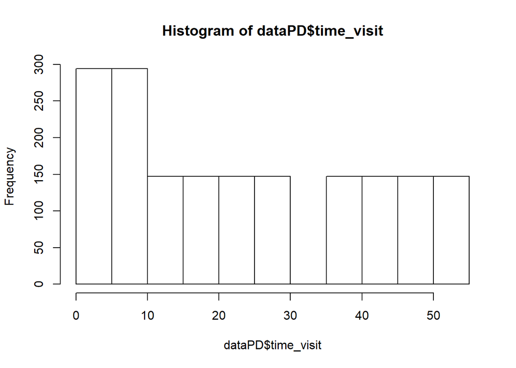

```r
hist(dataPD$time_visit)
```

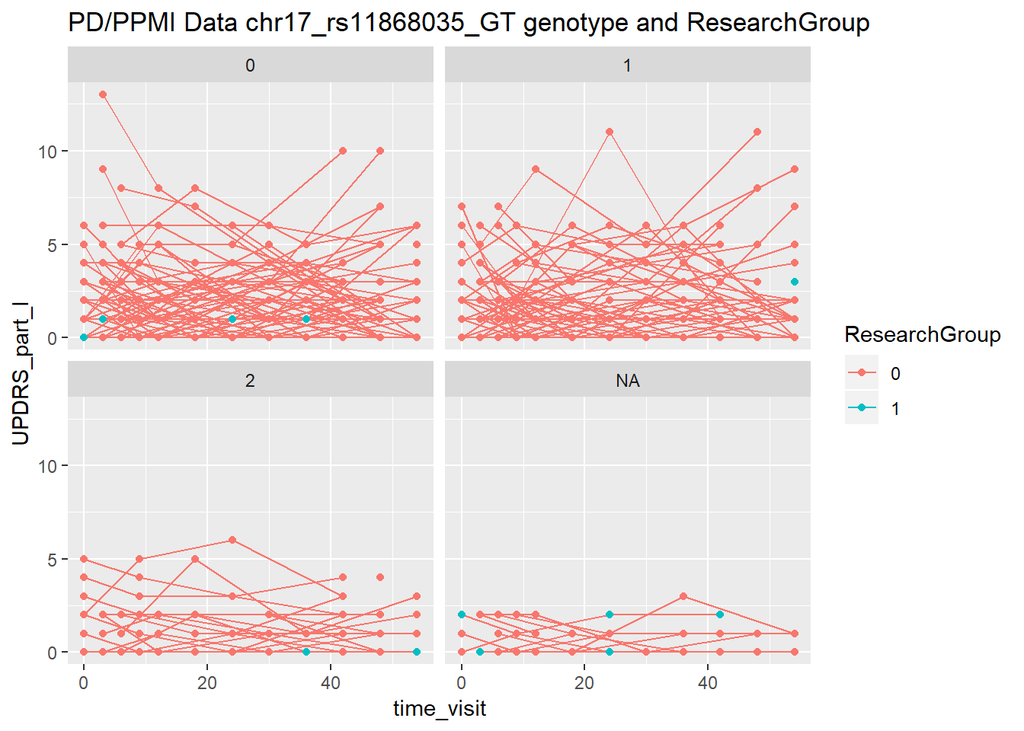

```r
# factorize the categorical features
dataPD_new <- dataPD
dataPD_new$ResearchGroup <- factor(dataPD_new$ResearchGroup)
dataPD_new$Sex <- factor(dataPD_new$Sex)
dataPD_new$chr12_rs34637584_GT <- factor(dataPD_new$chr12_rs34637584_GT)
dataPD_new$chr17_rs11868035_GT <- factor(dataPD_new$chr17_rs11868035_GT)

# by chr17_rs11868035_GT genotype and ResearchGroup
ggplot(dataPD_new, aes(x=time_visit, y=UPDRS_part_I, group=FID_IID)) +
  ggtitle("PD/PPMI Data chr17_rs11868035_GT genotype and ResearchGroup") +
  geom_line(aes(color=ResearchGroup)) +
  geom_point(aes(color=ResearchGroup)) + facet_wrap(~chr17_rs11868035_GT)
```

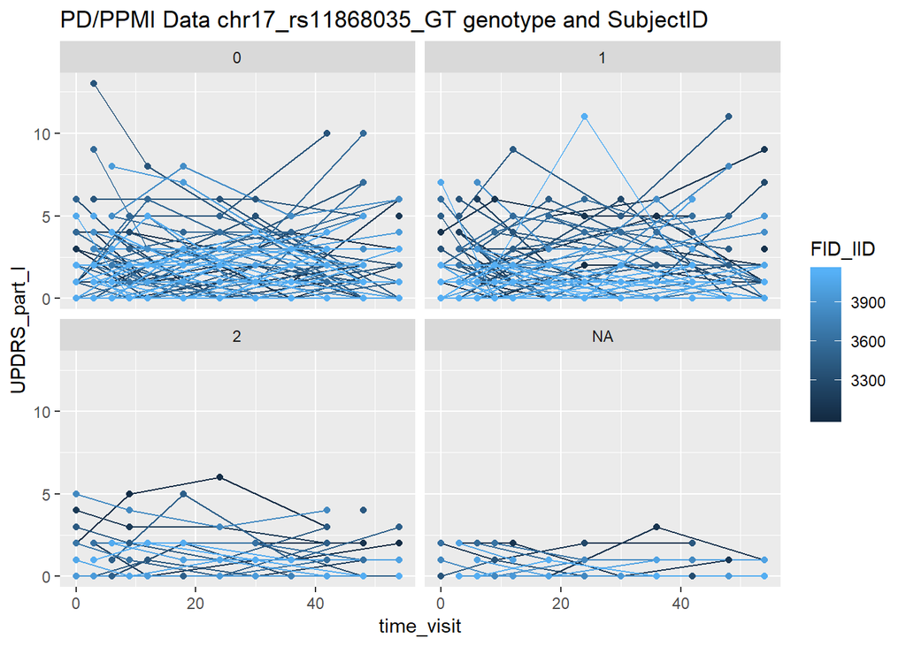

```r
# by chr17_rs11868035_GT genotype and subjectID
ggplot(dataPD_new, aes(x=time_visit, y=UPDRS_part_I, group=FID_IID)) +
  ggtitle("PD/PPMI Data chr17_rs11868035_GT genotype and SubjectID") +
  geom_line(aes(color=FID_IID)) +
  geom_point(aes(color=FID_IID)) +
  facet_wrap(~chr17_rs11868035_GT)
```

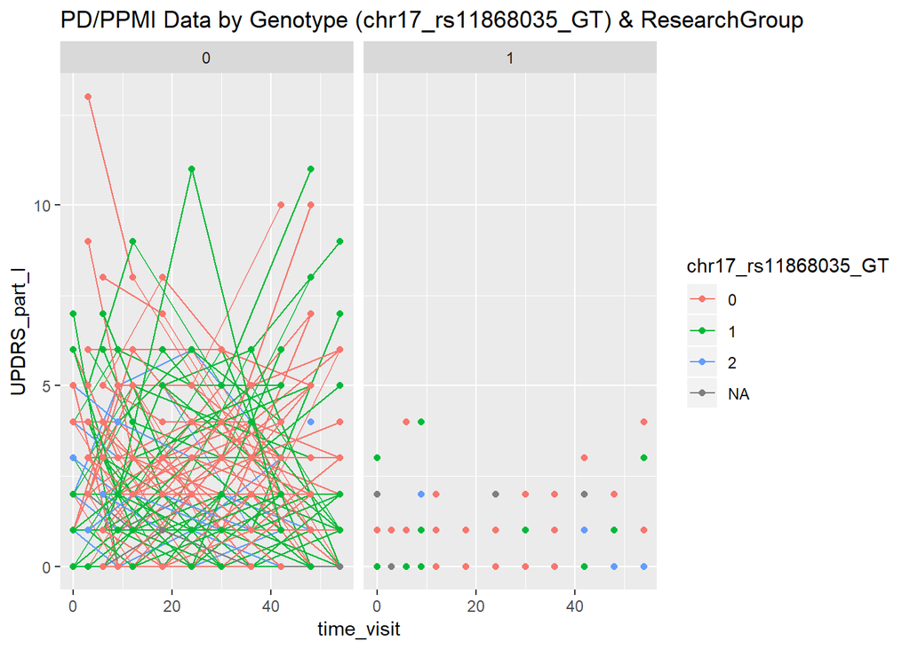

```r
# by ResearchGroup and chr17_rs11868035_GT genotype
ggplot(dataPD_new, aes(x=time_visit, y=UPDRS_part_I, group=FID_IID)) +
  ggtitle("PD/PPMI Data by Genotype (chr17_rs11868035_GT) & ResearchGroup") +
  geom_line(aes(color=chr17_rs11868035_GT))+
  geom_point(aes(color=chr17_rs11868035_GT))+
  facet_wrap(~ResearchGroup)
```

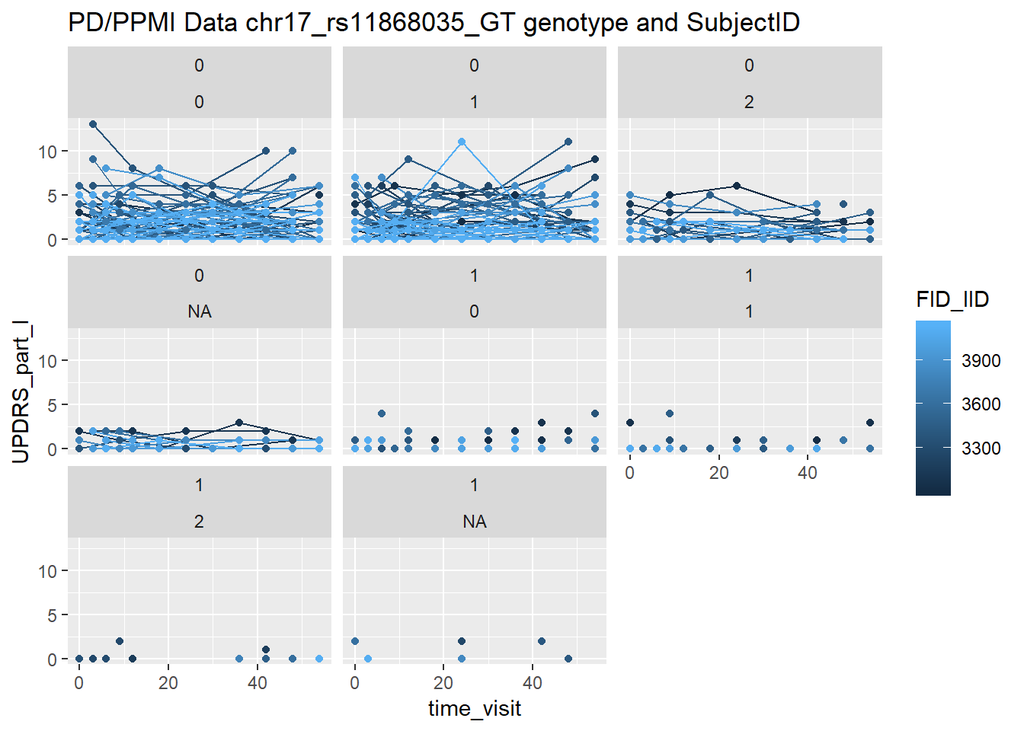

```r
# by ResearchGroup + chr17_rs11868035_GT genotype subgroups
ggplot(dataPD_new, aes(x=time_visit, y=UPDRS_part_I, group=FID_IID)) +
  ggtitle("PD/PPMI Data chr17_rs11868035_GT genotype and SubjectID") +
  geom_line(aes(color=FID_IID))+
  geom_point(aes(color=FID_IID))+
  facet_wrap(~ResearchGroup + chr17_rs11868035_GT)
```

## 5.2 SEM

```r
# time_visit is incongruent between cases, we make it ordinal category
# conver the long-to-wide data format to unwind the time
library(reshape2)

# check this R-blog post for some common data aggregation, melting, casting and other operations ...
# https://www.r-statistics.com/2012/01/aggregation-and-restructuring-data-from-r-in-action/

subsetPD <-
  dataPD[, c(
    "FID_IID",
    "L_insular_cortex_ComputeArea",
    "R_insular_cortex_ComputeArea",
    "L_cingulate_gyrus_ComputeArea",
    "R_cingulate_gyrus_ComputeArea",
    "L_putamen_Volume" ,
    "R_putamen_Volume",
    "Sex"  ,
    "Weight" ,
    "ResearchGroup" ,
    "Age" ,
    "chr12_rs34637584_GT" ,
    "chr17_rs11868035_GT",
    "UPDRS_part_I",
    "UPDRS_part_II" ,
    "UPDRS_part_III",
    "time_visit"
  )]

subsetPD$time_visit <-
  c("T1", "T2", "T3", "T4")   # convert all times to 1:4

# First Wide to long for UPDRS variable.names
subsetPD_long <-
  melt(
    subsetPD,
    id.vars = c(
      "FID_IID",
      "L_insular_cortex_ComputeArea",
      "R_insular_cortex_ComputeArea",
      "L_cingulate_gyrus_ComputeArea",
      "R_cingulate_gyrus_ComputeArea",
      "L_putamen_Volume" ,
      "R_putamen_Volume",
      "Sex"  ,
      "Weight" ,
      "ResearchGroup" ,
      "Age" ,
      "chr12_rs34637584_GT" ,
      "chr17_rs11868035_GT",
      "time_visit"
    ),
    variable.name = "UPDRS",
    value.name = "UPDRS_value"
  )

# Need to concatenate 2 columns "UPDRS" & "time_visit"
subsetPD_long$UPDRS_Time <-
  do.call(paste, c(subsetPD_long[c("UPDRS", "time_visit")], sep = "_"))
# remove the old "UPDRS" & "time_visit" columns
subsetPD_long1 <-
  subsetPD_long[,!(names(subsetPD_long) %in% c("UPDRS", "time_visit"))]
# View(subsetPD_long1)

# Convert Long to Wide format
library(reshape2)
# From the source:
# "FID_IID", "L_insular_cortex_ComputeArea",  "R_insular_cortex_ComputeArea", "L_cingulate_gyrus_ComputeArea", "R_cingulate_gyrus_ComputeArea", "L_putamen_Volume" ,  "R_putamen_Volume",  "Sex"  , "Weight" ,   "ResearchGroup" , "Age" , "chr12_rs34637584_GT" , "chr17_rs11868035_GT", are columns we want to keep the same
# "time_visit" is the column that contains the names of the new columns to put things in
# "UPDRS_part_I", "UPDRS_part_II" , "UPDRS_part_III" hold the measurements
subsetPD_wide <-
  dcast(
    subsetPD_long,
    FID_IID + L_insular_cortex_ComputeArea + R_insular_cortex_ComputeArea +
      L_cingulate_gyrus_ComputeArea + R_cingulate_gyrus_ComputeArea + L_putamen_Volume +
      R_putamen_Volume + Sex + Weight + ResearchGroup + Age + chr12_rs34637584_GT +
      chr17_rs11868035_GT ~ UPDRS_Time,
    value.var = "UPDRS_value",
    fun.aggregate = mean
  )

# Variables:
# "FID_IID", "L_insular_cortex_ComputeArea" ,"R_insular_cortex_ComputeArea",  "L_cingulate_gyrus_ComputeArea","R_cingulate_gyrus_ComputeArea","L_putamen_Volume", "R_putamen_Volume", "Sex","Weight", "ResearchGroup" ,"Age" , "chr12_rs34637584_GT", "chr17_rs11868035_GT","UPDRS_part_I_T1","UPDRS_part_I_T2"               "UPDRS_part_I_T3", "UPDRS_part_I_T4", "UPDRS_part_II_T1","UPDRS_part_II_T2","UPDRS_part_II_T3", "UPDRS_part_II_T4","UPDRS_part_III_T1","UPDRS_part_III_T2", "UPDRS_part_III_T3", "UPDRS_part_III_T4"

# SEM modeling
model1 <- '
# latent variable definitions - defining how the latent variables are "manifested by" a set of observed
# (or manifest) variables, aka "indicators"
# (1) Measurement Model
Imaging =~ L_cingulate_gyrus_ComputeArea + R_cingulate_gyrus_ComputeArea + L_putamen_Volume + R_putamen_Volume
DemoGeno =~ Weight+Sex+Age
UPDRS =~ UPDRS_part_I_T1
# UPDRS =~ UPDRS_part_II_T1 + UPDRS_part_II_T2 + UPDRS_part_II_T3 + UPDRS_part_II_T4

# (2) Regressions
ResearchGroup ~ Imaging + DemoGeno + UPDRS
'

# confirmatory factor analysis (CFA)
# The baseline is a null model constraining the observed variables to covary with no other variables.
# That is, the covariances are fixed to 0 and only individual variances are estimated. This is represents
# a "reasonable worst-possible fitting model", against which the new fitted model is compared
# to calculate appropriate model-quality indices (e.g., CFA).

summary(subsetPD_wide)
```

```
##     FID_IID     L_insular_cortex_ComputeArea R_insular_cortex_ComputeArea
##  Min.   :3001   Min.   :  50.03              Min.   :  40.92
##  1st Qu.:3272   1st Qu.:1976.88              1st Qu.:1345.72
##  Median :3476   Median :2498.65              Median :1889.61
##  Mean   :3534   Mean   :2255.20              Mean   :1710.72
##  3rd Qu.:3817   3rd Qu.:2744.05              3rd Qu.:2115.76
##  Max.   :4139   Max.   :3650.81              Max.   :2791.92
##
##  L_cingulate_gyrus_ComputeArea R_cingulate_gyrus_ComputeArea
##  Min.   : 127.8                Min.   : 104.1
##  1st Qu.:2379.5                1st Qu.:2311.6
##  Median :3654.1                Median :3658.9
##  Mean   :3314.9                Mean   :3277.2
##  3rd Qu.:4198.0                3rd Qu.:4211.6
##  Max.   :5944.2                Max.   :6593.7
##
##  L_putamen_Volume   R_putamen_Volume        Sex           Weight
##  Min.   :   1.228   Min.   :   3.207   Min.   :1.00   Min.   : 43.20
##  1st Qu.: 916.762   1st Qu.:1805.159   1st Qu.:1.00   1st Qu.: 70.50
##  Median :1792.465   Median :3380.443   Median :1.00   Median : 81.20
##  Mean   :1764.358   Mean   :2965.016   Mean   :1.34   Mean   : 82.05
##  3rd Qu.:2507.000   3rd Qu.:3959.362   3rd Qu.:2.00   3rd Qu.: 90.90
##  Max.   :4712.661   Max.   :7096.580   Max.   :2.00   Max.   :135.00
##
##  ResearchGroup         Age        chr12_rs34637584_GT chr17_rs11868035_GT
##  Min.   :0.0000   Min.   :31.18   Min.   :0.000000    Min.   :0.0000
##  1st Qu.:0.0000   1st Qu.:54.07   1st Qu.:0.000000    1st Qu.:0.0000
##  Median :0.0000   Median :62.15   Median :0.000000    Median :1.0000
##  Mean   :0.2902   Mean   :61.07   Mean   :0.009479    Mean   :0.6161
##  3rd Qu.:1.0000   3rd Qu.:68.82   3rd Qu.:0.000000    3rd Qu.:1.0000
##  Max.   :1.0000   Max.   :83.03   Max.   :1.000000    Max.   :2.0000
##                                   NA's   :19          NA's   :19
##  UPDRS_part_I_T1 UPDRS_part_I_T2 UPDRS_part_I_T3  UPDRS_part_I_T4
##  Min.   : 0.00   Min.   :0.000   Min.   : 0.000   Min.   : 0.000
##  1st Qu.: 0.00   1st Qu.:0.000   1st Qu.: 0.000   1st Qu.: 0.000
##  Median : 1.00   Median :1.000   Median : 1.000   Median : 1.000
##  Mean   : 1.32   Mean   :1.252   Mean   : 1.295   Mean   : 1.279
##  3rd Qu.: 2.00   3rd Qu.:2.000   3rd Qu.: 2.000   3rd Qu.: 2.000
##  Max.   :13.00   Max.   :9.000   Max.   :11.000   Max.   :11.000
##  NA's   :141     NA's   :139     NA's   :133      NA's   :136
##  UPDRS_part_II_T1 UPDRS_part_II_T2 UPDRS_part_II_T3 UPDRS_part_II_T4
##  Min.   : 0.000   Min.   : 0.000   Min.   : 0.000   Min.   : 0.000
##  1st Qu.: 2.000   1st Qu.: 2.000   1st Qu.: 2.000   1st Qu.: 2.000
##  Median : 5.000   Median : 5.000   Median : 5.000   Median : 5.000
##  Mean   : 5.983   Mean   : 5.947   Mean   : 6.208   Mean   : 6.204
##  3rd Qu.: 9.000   3rd Qu.: 8.000   3rd Qu.: 8.000   3rd Qu.: 9.000
##  Max.   :28.000   Max.   :24.000   Max.   :27.000   Max.   :28.000
##  NA's   :143      NA's   :140      NA's   :133      NA's   :137
##  UPDRS_part_III_T1 UPDRS_part_III_T2 UPDRS_part_III_T3 UPDRS_part_III_T4
##  Min.   : 0.00     Min.   : 0.0      Min.   : 0.00     Min.   : 0.00
##  1st Qu.:12.00     1st Qu.:12.0      1st Qu.:11.75     1st Qu.:11.00
##  Median :19.00     Median :19.5      Median :20.50     Median :19.00
##  Mean   :19.27     Mean   :19.7      Mean   :19.55     Mean   :19.24
##  3rd Qu.:27.00     3rd Qu.:26.0      3rd Qu.:26.00     3rd Qu.:27.00
##  Max.   :56.00     Max.   :59.0      Max.   :53.00     Max.   :61.00
##  NA's   :141       NA's   :141       NA's   :133       NA's   :139
```

```r
# selective scale features (e.g., avoid scaling Subject ID's)
dataPD2 <-
  as.data.frame(cbind(scale(subsetPD_wide[,!(
    names(subsetPD_wide) %in% c(
      "FID_IID",
      "Sex",
      "ResearchGroup",
      "chr12_rs34637584_GT",
      "chr17_rs11868035_GT"
    )
  )]), subsetPD_wide[, (
    names(subsetPD_wide) %in% c(
      "FID_IID",
      "Sex",
      "ResearchGroup",
      "chr12_rs34637584_GT",
      "chr17_rs11868035_GT"
    )
  )]))

summary(dataPD2)
```

```
##  L_insular_cortex_ComputeArea R_insular_cortex_ComputeArea
##  Min.   :-2.9519              Min.   :-2.7598
##  1st Qu.:-0.3726              1st Qu.:-0.6033
##  Median : 0.3259              Median : 0.2957
##  Mean   : 0.0000              Mean   : 0.0000
##  3rd Qu.: 0.6544              3rd Qu.: 0.6694
##  Max.   : 1.8682              Max.   : 1.7870
##
##  L_cingulate_gyrus_ComputeArea R_cingulate_gyrus_ComputeArea
##  Min.   :-2.4781               Min.   :-2.3860
##  1st Qu.:-0.7273               1st Qu.:-0.7261
##  Median : 0.2638               Median : 0.2871
##  Mean   : 0.0000               Mean   : 0.0000
##  3rd Qu.: 0.6867               3rd Qu.: 0.7027
##  Max.   : 2.0444               Max.   : 2.4939
##
##  L_putamen_Volume   R_putamen_Volume      Weight              Age
##  Min.   :-1.60644   Min.   :-1.9280   Min.   :-2.34105   Min.   :-2.9093
##  1st Qu.:-0.77227   1st Qu.:-0.7550   1st Qu.:-0.69589   1st Qu.:-0.6811
##  Median : 0.02561   Median : 0.2704   Median :-0.05108   Median : 0.1044
##  Mean   : 0.00000   Mean   : 0.0000   Mean   : 0.00000   Mean   : 0.0000
##  3rd Qu.: 0.67664   3rd Qu.: 0.6473   3rd Qu.: 0.53347   3rd Qu.: 0.7544
##  Max.   : 2.68628   Max.   : 2.6895   Max.   : 3.19104   Max.   : 2.1371
##
##  UPDRS_part_I_T1   UPDRS_part_I_T2   UPDRS_part_I_T3   UPDRS_part_I_T4
##  Min.   :-0.7479   Min.   :-0.7722   Min.   :-0.8014   Min.   :-0.7018
##  1st Qu.:-0.7479   1st Qu.:-0.7722   1st Qu.:-0.8014   1st Qu.:-0.7018
##  Median :-0.1813   Median :-0.1552   Median :-0.1828   Median :-0.1530
##  Mean   : 0.0000   Mean   : 0.0000   Mean   : 0.0000   Mean   : 0.0000
##  3rd Qu.: 0.3853   3rd Qu.: 0.4617   3rd Qu.: 0.4359   3rd Qu.: 0.3959
##  Max.   : 6.6182   Max.   : 4.7801   Max.   : 6.0038   Max.   : 5.3352
##  NA's   :141       NA's   :139       NA's   :133       NA's   :136
##  UPDRS_part_II_T1  UPDRS_part_II_T2  UPDRS_part_II_T3  UPDRS_part_II_T4
##  Min.   :-1.1880   Min.   :-1.2605   Min.   :-1.2222   Min.   :-1.1782
##  1st Qu.:-0.7909   1st Qu.:-0.8366   1st Qu.:-0.8284   1st Qu.:-0.7984
##  Median :-0.1952   Median :-0.2007   Median :-0.2378   Median :-0.2286
##  Mean   : 0.0000   Mean   : 0.0000   Mean   : 0.0000   Mean   : 0.0000
##  3rd Qu.: 0.5990   3rd Qu.: 0.4352   3rd Qu.: 0.3528   3rd Qu.: 0.5310
##  Max.   : 4.3717   Max.   : 3.8266   Max.   : 4.0934   Max.   : 4.1393
##  NA's   :143       NA's   :140       NA's   :133       NA's   :137
```

[output cut: 9 more lines]

```
##  Min.   :-1.61225   Min.   :3001   Min.   :1.00   Min.   :0.0000
##  1st Qu.:-0.69041   1st Qu.:3272   1st Qu.:1.00   1st Qu.:0.0000
##  Median :-0.01998   Median :3476   Median :1.00   Median :0.0000
##  Mean   : 0.00000   Mean   :3534   Mean   :1.34   Mean   :0.2902
##  3rd Qu.: 0.65045   3rd Qu.:3817   3rd Qu.:2.00   3rd Qu.:1.0000
##  Max.   : 3.49977   Max.   :4139   Max.   :2.00   Max.   :1.0000
##  NA's   :139
##  chr12_rs34637584_GT chr17_rs11868035_GT
##  Min.   :0.000000    Min.   :0.0000
##  1st Qu.:0.000000    1st Qu.:0.0000
##  Median :0.000000    Median :1.0000
##  Mean   :0.009479    Mean   :0.6161
##  3rd Qu.:0.000000    3rd Qu.:1.0000
##  Max.   :1.000000    Max.   :2.0000
##  NA's   :19          NA's   :19
```

```r
# fitSEM3 <- cfa(model3, data= dataPD2, missing='FIML')         # deal with missing values (missing='FIML')
# summary(fitSEM3, fit.measures=TRUE)

fitSEM1 <- sem(model1, data = dataPD2, estimator = "MLM")
# Check the SEM model covariances
fitSEM1@SampleStats@cov
```

```
## [[1]]
##              [,1]        [,2]        [,3]         [,4]        [,5]
##  [1,]  0.95956912  0.92782403  0.78283377  0.835298387 -0.06703561
##  [2,]  0.92782403  0.98399423  0.75987211  0.826743747 -0.11977115
##  [3,]  0.78283377  0.75987211  0.95770937  0.773935820 -0.11919267
##  [4,]  0.83529839  0.82674375  0.77393582  0.952544632 -0.10169577
##  [5,] -0.06703561 -0.11977115 -0.11919267 -0.101695772  1.03597971
##  [6,]  0.01775591  0.02678867  0.03040808  0.006859358 -0.25810986
##  [7,] -0.10671796 -0.06184763 -0.20096949 -0.090396010 -0.04142229
##  [8,] -0.12283335 -0.13481718 -0.11266620 -0.082008720 -0.04988071
##  [9,] -0.03313195 -0.03972296 -0.03136488 -0.021440312  0.01528020
##               [,6]        [,7]        [,8]        [,9]
##  [1,]  0.017755907 -0.10671796 -0.12283335 -0.03313195
##  [2,]  0.026788671 -0.06184763 -0.13481718 -0.03972296
##  [3,]  0.030408083 -0.20096949 -0.11266620 -0.03136488
##  [4,]  0.006859358 -0.09039601 -0.08200872 -0.02144031
##  [5,] -0.258109861 -0.04142229 -0.04988071  0.01528020
##  [6,]  0.224400000 -0.03939143  0.06111991 -0.01180000
##  [7,] -0.039391431  0.93245182  0.07279791 -0.02289684
##  [8,]  0.061119911  0.07279791  0.99666667 -0.05273387
##  [9,] -0.011800000 -0.02289684 -0.05273387  0.09265556
```

```r
summary(fitSEM1)
```

```
## lavaan 0.6-2 ended normally after 350 iterations
##
##   Optimization method                           NLMINB
##   Number of free parameters                         22
##
##                                                   Used       Total
##   Number of observations                           300         441
##
##   Estimator                                         ML      Robust
##   Model Fit Test Statistic                      89.487      83.762
##   Degrees of freedom                                23          23
##   P-value (Chi-square)                           0.000       0.000
##   Scaling correction factor                                  1.068
##     for the Satorra-Bentler correction
##
## Parameter Estimates:
##
##   Information                                 Expected
##   Information saturated (h1) model          Structured
##   Standard Errors                           Robust.sem
##
## Latent Variables:
##                    Estimate  Std.Err  z-value  P(>|z|)
##   Imaging =~
##     L_cnglt_gyr_CA    1.000
##     R_cnglt_gyr_CA    0.990    0.020   49.745    0.000
##     L_putamen_Volm    0.838    0.034   24.484    0.000
##     R_putamen_Volm    0.896    0.029   30.633    0.000
##   DemoGeno =~
##     Weight            1.000
##     Sex               6.472   31.183    0.208    0.836
##     Age               0.213    0.091    2.345    0.019
##   UPDRS =~
##     UPDRS_prt_I_T1    1.000
##
## Regressions:
##                    Estimate  Std.Err  z-value  P(>|z|)
##   ResearchGroup ~
##     Imaging          -0.044    0.020   -2.229    0.026
##     DemoGeno          0.024    0.023    1.077    0.281
```

[output cut: 9 more lines]

```
##
## Variances:
##                    Estimate  Std.Err  z-value  P(>|z|)
##    .L_cnglt_gyr_CA    0.024    0.009    2.588    0.010
##    .R_cnglt_gyr_CA    0.067    0.010    6.642    0.000
##    .L_putamen_Volm    0.300    0.031    9.545    0.000
##    .R_putamen_Volm    0.201    0.027    7.460    0.000
##    .Weight            1.076    0.229    4.698    0.000
##    .Sex               1.885    8.005    0.235    0.814
##    .Age               0.934    0.073   12.861    0.000
##    .UPDRS_prt_I_T1    0.000
##    .ResearchGroup     0.088    0.013    6.934    0.000
##     Imaging           0.936    0.074   12.653    0.000
##     DemoGeno         -0.040    0.191   -0.208    0.836
##     UPDRS             0.997    0.181    5.505    0.000
```

```r
# report the standardized coefficients of the model
# standardizedSolution(fitSEM1)
# variation explained by model components (The R-square value for all endogenous variables)
inspect(fitSEM1, "r2")  # lavInspect()
```

```
## L_cingulate_gyrus_ComputeArea R_cingulate_gyrus_ComputeArea
##                         0.975                         0.932
##              L_putamen_Volume              R_putamen_Volume
##                         0.687                         0.789
##                        Weight                           Sex
##                        -0.038                        -7.400
##                           Age               UPDRS_part_I_T1
##                        -0.002                         1.000
##                 ResearchGroup
##                         0.049
```

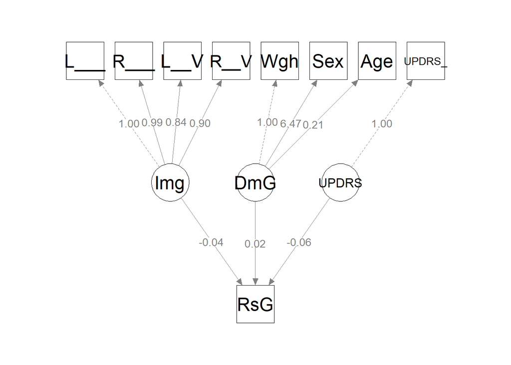

```r
# install.packages("semPlot")
library(semPlot)
semPlot::semPaths(
  fitSEM1,
  intercept = FALSE,
  whatLabel = "est",
  residuals = FALSE,
  exoCov = FALSE,
  edge.label.cex = 1.0,
  label.cex = 1.5,
  sizeMan = 8
)
```